# Tax Evasion and Productivity

Hans Martinez

Western University

September 21, 2026

## Recap

Last meeting: What is an interesting question to wrap up the JMP?

- Counterfactual question: Optimal tax rate

Today:

- SOC of firm’s optimization problem
- Functional forms for detection probability and tax evasion cost
- Estimation strategy

$\hookrightarrow$

## Introduction

- What’s the question?
- Why should you care?

## Contribution

- What do I do?
- How do I do it?

## Overview of Results

- What do I find?
- Why is it important?

## Colombia

# Model

## The Model

$$\begin{aligned}
\max_{K_{it},L_{it},M_{it}, e_{it}} \big(1-q(e_{it})\big)&\bigg[P_t\mathbb{E}_{\varepsilon}[Y_{it}]-\rho_{t} M_{it}-r_tK_{it}-w_tL_{it}\\
&-\tau\left(P_t\mathbb{E}_{\varepsilon}[Y_{it}]-\rho_{t} (M_{it}+e_{it})\right)\bigg]\\
+q(e_{it})&\bigg[(1-\tau)(P_t\mathbb{E}_{\varepsilon}[Y_{it}]-\rho_{t} M_{it})-r_tK_{it}-w_tL_{it}\\
&-\phi\rho_t\tau e_{it}\bigg]-\kappa_{it}(e_{it}, \omega_{it}) \\
\text{s.t. }\; Y_{it}&=K_{it}^{\alpha_k}L_{it}^{\alpha_L}M_{it}^{\beta}\exp(\omega_{it}+\varepsilon_{it})
\end{aligned}
\tag{1}$$

## Important Assumptions

- Following seminal work of Allingham and Sandmo (1972), tax authority audits firms at random and always detects tax evasion
  - The probability of detection, $q(e_{it})$, is a function of the level of tax evasion, $e_{it}$. It might depend on other exogenous variables such as the monitoring technology of the tax authority, for example.
  - Impose assumption from Empirical model which assumes that choosing M does not enter the probability of detection or the cost of evasion. In other words, choosing M is independent of choosing e.

## Important Assumptions (Cont.)

The cost of evasion, $\kappa_{it}(e_{it}, \omega_{it})$: any resources of the firm allocated to the tax evasion activity that could have been employed in a productive activity (e.g. manager’s time spent on tax evasion instead of managing the firm).

- Unlike the penalty of tax evasion, $\phi$, it does not depend on whether you are detected or not
- Increasing in the level of tax evasion, $e_{it}$
- Decreasing in firm’s productivity, $\omega_{it}$, but spikes at the top of the productivity distribution.

## Important Assumptions - discussion on $\kappa$

- More productive firms have more resources to allocate to tax evasion, but since huge firms have access to more sophisticated legal tax avoidance strategies, the cost of illegal tax evasion is higher for the most productive firms.
- It could also be the case that the probability of detection is flat with respect to productivity except for huge (top productive) firms which could have a probability close to 1.
- Empirically, without data on cost of evasion or auditing information, $q$ and $\kappa$ are not separately identified. During estimation, we assume functional forms that allow us to reproduce the empirical patterns of tax evasion across the productivity distribution.

## Model (Cont.)

The firms’ problem (Equation 1) can be rewritten as follows,
$$\begin{aligned}
\max_{K_{it}, L_{it},M_{it},e_{it}} \mathbb{E}[\pi_{it}|\Gamma] = &(1-\tau)\left(P_t\mathbb{E}[Y_{it}]-\rho_{t} M_{it}\right)-r_tK_{it}\\
&-w_tL_{it}+[1-q(e_{it})]\left(\rho_{t}\tau e_{it}\right)-q(e_{it})\phi\rho_t\tau e_{it}\\
&-\kappa_{it}(e_{it}, \omega_{it}) \\
\text{s.t. }\; Y_{it}&=K_{it}^{\alpha_k}L_{it}^{\alpha_L}M_{it}^{\beta}\exp(\omega_{it}+\varepsilon_{it})
\end{aligned}
\tag{2}$$

## First Order Condition (FOC)

An interior solution leads to following first-order conditions,

$$\beta K_{it}^{\alpha_K}L_{it}^{\alpha_L}M_{it}^{-(1-\beta)}\exp(\omega_{it})=\frac{\rho_{t}}{P_t}
\tag{3}$$

$$\tau\rho_t\left(1-(1+\phi)\left(q(e_{it})+q'(e_{it}) e_{it}\right)\right) =\frac{\partial \kappa_{it}(e_{it}, \omega_{it})}{\partial e_{it}}
\tag{4}$$

($\varepsilon_{ijt}$ is measurement error, so $\mathcal{E}\equiv E[\exp(\varepsilon_{ijt})]=1$)

$\hookrightarrow$

## Tax Evasion

To better understand the incentives to overreport inputs, we can rewrite Equation 4 in terms of the evasion elasticity of the probability of detection, $\xi_{q,e}=\frac{\partial q(e_{it})}{\partial e_{it}}\frac{e_{it}}{q(e_{it})}$, as follows,

$$\tau\rho_t\bigg(1-(1+\phi)\left(1+\xi_{q,e}\right)q(e_{it})\bigg) =\frac{\partial \kappa_{it}(e_{it},\omega_{it})}{\partial e_{it}}
\tag{5}$$

## Corner Solution

Note that some firms will optimally choose not to evade, $e_{it}=0$.

For these firms, the marginal cost of tax evasion is greater than the marginal benefit for any non-zero level of tax evasion.

This implies that for these firms, Equation 4 becomes,

$$\tau\rho_t \le \frac{\partial \kappa_{it}(0, \omega_{it})}{\partial e_{it}}
\tag{6}$$

$\hookrightarrow$

## Second Order Condition (SOC)

To gurantee a unique solution, the hessian matrix of the firm’s problem must be negative definite.

$$\nabla^2 \mathbb{E}[\pi_{it}|\Gamma] = \begin{bmatrix}
\frac{\partial^2 \mathbb{E}[\pi_{it}|\Gamma]}{\partial e_{it}^2} & 0 & 0 & 0 \\
0 & \frac{\partial^2 \mathbb{E}[\pi_{it}|\Gamma]}{\partial M_{it}^2} & \frac{\partial^2 \mathbb{E}[\pi_{it}|\Gamma]}{\partial M_{it}\partial L_{it}} & \frac{\partial^2 \mathbb{E}[\pi_{it}|\Gamma]}{\partial M_{it}\partial K_{it}} \\
0 & \frac{\partial^2 \mathbb{E}[\pi_{it}|\Gamma]}{\partial L_{it}\partial M_{it}} & \frac{\partial^2 \mathbb{E}[\pi_{it}|\Gamma]}{\partial L_{it}^2} & \frac{\partial^2 \mathbb{E}[\pi_{it}|\Gamma]}{\partial L_{it}\partial K_{it}} \\
0 & \frac{\partial^2 \mathbb{E}[\pi_{it}|\Gamma]}{\partial K_{it}\partial M_{it}} & \frac{\partial^2 \mathbb{E}[\pi_{it}|\Gamma]}{\partial K_{it}\partial L_{it}} & \frac{\partial^2 \mathbb{E}[\pi_{it}|\Gamma]}{\partial K_{it}^2}
\end{bmatrix}
\tag{7}$$

## SOC

- For a negative definite hessian matrix, the leading principal minors must alternate signs,
  - odd order minors must be negative and even-order minors positive.
- In our case, since
  - 1. the production function is strictly concave (CD) and
  - 2. choosing the level of tax evasion does not depend on the production function inputs; second cross derivaties are zero,
  - we would only have to check the first leading principal minor —the second derivative with respect to $e_{it}$— is negative,

$$\frac{\partial^2 \mathbb{E}[\pi_{it}|\Gamma]}{\partial e_{it}^2} = -\tau\rho_t(1+\phi)\left(2 q'(e_{it})+ e_{it}q''(e_{it})\right) - \frac{\partial^2\kappa_{it}(e_{it}, \omega_{it})}{\partial e_{it}^2} < 0
\tag{8}$$

## SOC

For strict concavity, we need only one of the following two conditions to be strictly positive,

$$\frac{\partial^2\kappa_{it}(e_{it}, \omega_{it})}{\partial e_{it}^2} \ge 0
\tag{9}$$

$$\tau\rho_t(1+\phi)\left(2 q'(e_{it})+ e_{it}q''(e_{it})\right) \ge 0
\tag{10}$$

## SOC

The second condition can be simplified to

$$-\frac{q''(e_{it})}{q'(e_{it})}e_{it} < 2
\tag{11}$$

since economic theory implies that $q'(e_{it})>0$ and $e_{it}>0$, this condition imposes a **restriction on the curvature** of the detection function, $q(e_{it})$

- **Linear** detection **always** satisfies the SOC, since $q''(e_{it})=0$.
- **Convex** also satisfies the SOC **always**, since $q''(e_{it})>0$.
- **Concave** works if not too concave, i.e. **inequality holds**.

## What does this inequality imply in practice?

With $\phi=0$, logs of the interior FOC $\tau\rho_t(1-q-q'e)=\partial\kappa/\partial e$ define

- the **log marginal benefit** $h(e)\equiv\ln(\tau\rho_t)+\ln(1-q(e)-q'(e)e)$,
  - with FOC $h(e)=\ln(\partial\kappa/\partial e)$.

|  | $q(e)$ | SOC | $h(e)-\ln(\tau\rho_t)$ | FOC ceiling |
| --- | --- | --- | --- | --- |
| Linear | $\min\{\lambda e,1\}$ | $0<2$ | $\ln(1-2\lambda e)$ | $\lambda e<\tfrac12$ |
| Concave | $1-\textbf{e}^{-\lambda e}$ | $\lambda e<2$ | $-\lambda e+\ln(1-\lambda e)$ | $\lambda e<1$ |
| Convex | $\min\{(\lambda e)^k,1\}$ $k>1$ | $1-k<2$ | $\ln(1-(1{+}k)(\lambda e)^k)$ | $\lambda e<(1{+}k)^{-1/k}$ |

- All satisfy the SOC on their interior (exp’s $\lambda e<2 \impliedby \lambda e<1$);
- All impose a restriction on $\lambda e$.

## A detection technology: the audit threshold

- The firm chooses overreporting $e$.
- The tax authority draws a threshold $T\sim U[0,1/\lambda]$ and audits the firm if $e\ge T$.
  - An audit always uncovers evasion (Allingham and Sandmo 1972).
  - $T$ is random to the firm (audit selection, third-party cross-checks, which inspector).

$$q(e)=\Pr(T\le e)=\min\{\lambda e,1\}.$$

- **Threshold scale**: $1/\lambda$ is the largest overreporting any audit draw tolerates; the *average* audit-triggering threshold is $1/2\lambda$.
- **Evasion bound**: the FOC stops firms at $\lambda e<\tfrac12$
  - the most aggressive evader overreports below the *average* audit-triggering threshold,
  - at threshold, $q(1/2\lambda)=50\%$ (a coin flip)

If $q(e)$ is concave, $T\sim\text{Exp}(\lambda)$ and $q(e)=1-\textbf{e}^{-\lambda e}$, mean threshold $1/\lambda$, detection $\approx63\%$ at $e=1/\lambda$.

## How likely is the most aggressive evader caught?

At the FOC ceiling, the largest evasion drives the marginal benefit to zero, $q(b)+q'(b)b=1$.

|  | $b$ | $q(b)$ | $\left.\xi_{q,e}\right\|_{e=b}$ | $E[T]$ |
| --- | --- | --- | --- | --- |
| Linear | $\frac{1}{2\lambda}$ | $50\%$ | 1 (unit elastic) | $\frac{1}{2\lambda}$ |
| Exponential | $\frac{1}{\lambda}$ | $63\%$ | $\tfrac{\lambda b}{\textbf{e}^{\lambda b}-1}<1$ (inelastic) | $\frac{1}{\lambda}$ |
| Power | $\frac{1}{\lambda(1+k)^{1/k}}$ | $\tfrac{1}{1+k}<50\%$ | $k>1$ (elastic) | $\frac{k}{\lambda(k+1)}$ |

- $\xi_{q,e}=q'(e)e/q(e)$ is the evasion elasticity of the detection probability
- $\frac{1}{\textbf{e}-1}=0.58$

## Estimation and recommendation

- **Linear** and **exponential** carry a single parameter $\lambda$
- **Power** $(\lambda e)^k$ adds a parameter, curvature $k$

Do **linear** and **power**,

- Start with **linear** ($k=1$). Linear is the $k=1$ case of the power form (ceiling $(1{+}k)^{-1/k}=\tfrac12$).
- Then, estimate power $(\lambda,k)$, imposing feasibility $\lambda e<(1{+}k)^{-1/k}$ for *every* firm. Test if $k=1$.

$\hookrightarrow$

# The Counterfactual Question, Reframed

## From “What’s Optimal?” to “What’s the Derivative?”

The natural first framing — “what purchases-tax credit rate $\Delta$ maximizes government revenue?” — presupposes an interior optimum exists. It doesn’t, in general, under this revenue formula (next slides).

**What this section actually answers:** holding sales-tax revenue and firms’ optimal materials/output decisions fixed at their observed values, and letting only evasion respond — what is the *derivative* of government tax revenue with respect to a change in the purchases-side tax credit rate, at the current state?

A well-defined, always-computable local quantity — not a claim that some $\Delta^*$ exists.

## The Government’s Problem (Two-Tax Model)

Only $\tau_P$ enters the firm’s evasion FOC — $\tau_S$ never does. Shock $\tau_P\to(1+\Delta)\tau_P\equiv\tilde\tau_{P,it}$:

$$R_i(\Delta;M_i) = \underbrace{\tau_{S,it}P_tY_{it}}_{\text{sales-tax revenue, fixed}} - \tilde\tau_{P,it}\big[M_i+(1-q(\tilde e_i(\Delta)))\tilde e_i(\Delta)\big]$$

$M_i$ (true materials) held fixed for now — checked explicitly two slides from now. Corner firms ($\tau_P=0$): $R_i=\tau_{S,it}P_tY_{it}-\tilde\tau_{P,it}M^*_{it}$, no detection term.

## Closed Form: Evasion Under the Shock

Linear $q$, linear $\kappa$: new evasion is an exact linear function of the firm’s own baseline evasion, with a firm-invariant intercept:
$$\tilde e_i(\Delta) = \frac{e_i}{1+\Delta} + \frac{\Delta}{2\lambda(1+\Delta)},\qquad \text{clipped at }0$$
Mechanical consequence of $\kappa$ linear in $e$: marginal cost is a firm-type constant, not a function of $e$ — the FOC is linear, every firm’s optimum shifts by the same absolute amount.

## The Derivative, Holding $M$ Fixed

Let $x\equiv1+\Delta$. For ANY $q,\kappa$ (not just this linear spec) satisfying mild regularity — firm’s own SOC holds, $\kappa'>0$, detection not certain at the interior optimum — an envelope-theorem argument on the firm’s own FOC gives:
$$\frac{dR}{dx} = -\tau_P\rho_t\big[M+L(e^*(x))\big] - \kappa'(e^*(x))\frac{de^*}{dx} \;<\;0\quad\text{always},\qquad L(e)\equiv(1-q(e))e$$

**A structural result, not a functional-form artifact**: this revenue formula is a pure transfer between government and evading firms; nothing attaches a real resource cost to $x$. At the observed state ($\Delta=0$), and everywhere else with $M$ held fixed, raising the purchases credit always costs revenue on the margin — equivalently, cutting it always helps, on the margin, with materials/output held at their observed levels.

## Robustness: Does the True Materials Level Actually Respond?

$M$ was held fixed above — check it. The materials FOC (two-tax model) implies $M(x)\propto(1-x\tau_P)^{-1/(1-\beta)}$, $M'(x)>0$: a more generous credit lowers the net materials price, firms use more real materials. This makes $\tau_SP_tY(x)$ respond too:
$$\frac{dR}{dx} = \rho_tM'(x)\cdot\frac{\tau_S-x\tau_P}{1-\tau_S} - \tau_P\rho_t[M(x)+L(e^*(x))] - \kappa'(e^*(x))\frac{de^*}{dx}$$
New term positive whenever $x\tau_P<\tau_S$ — in principle a real channel the fixed-$M$ derivative misses.

## Numeric Check: Real, but Negligible

$\Delta=0$, median firm, sample medians ($\hat\beta=0.387,\hat\tau_P=0.088,\hat\tau_S=0.089$), headline $\hat\lambda=5.427\times10^{-7}$:

| term | value |
| --- | --- |
| output-growth (new) | $\approx+1.8$ |
| mechanical legit-credit | $\approx-819$ |
| evasion-response | $\approx-80{,}655$ |

## Scope

Both derivatives above describe the *local* response of revenue to $\Delta$, around the observed equilibrium, holding $K,L,\omega,\varepsilon$ fixed throughout — a comparative-statics exercise, not a general-equilibrium optimal-tax result. What’s estimated next (`620-ELVIS.qmd`, results in `650-stage2-prelim-results.qmd`) is exactly this: the revenue effect of small changes in $\Delta$ around the current state, with evasion the only margin that moves.

## Empirical Strategies

- Testing for the presence of tax evasion by industry
  - Robust to different specifications
- Regression
  - Useful to study tax evasion heterogeneity across firms and over time
- Deconvolution
  - Recover distribution of tax evasion and productivity
  - Estimation of unbiased Production Function

## Data

## Testing

# Entropic Latent Variable Integration via Simulation (ELVIS)

## ELVIS (Schennach (2014))

- The “Why not GMM” failure wasn’t fundamental — it was a *naive-averaging* bug: swapping in $\bar\ell_{it}(\lambda)$ silently drops the firm-specific reweighting
- Schennach (2014, *Econometrica*, “Entropic Latent Variable Integration via Simulation”) targets exactly this class: $E[g(U,Z,\theta)]=0$ with $U$ unobserved, $g$ arbitrary — nonlinear, nonmonotone, nonseparable
- Her own canonical example (errors-in-variables: unobserved true regressor $X^*$, observed $X=X^*+\Delta X$) is structurally our $M$ vs. $M^*$

## Recasting the moment in $M$

Take $M_{it}$ (true materials) — not $\varepsilon_{it}$ — as the one unobservable. Everything else is a deterministic function of $M$ and data:

$$\begin{aligned}
e(M)&=M^*_{it}-M,\qquad \varepsilon(M)=\ln(M^*_{it}/M)-\mathcal V_{it},\\
\omega(M)&=\tilde{\mathcal W}_{it}-(1-\beta)\varepsilon(M)
\end{aligned}$$

$$g(M,Z_{it},\theta)\;\equiv\;\psi(M)\;=\;h\big(e(M)\big)-\delta_0+\delta_1\omega(M)-\delta_2\omega(M)^2
\tag{12}$$

- Support $\mathcal U_{Z,\theta}=\big(M^*_{it}-\tfrac1{2\lambda},\,M^*_{it}\big)$ — the feasibility ceiling $e<1/(2\lambda)$ becomes the domain, not a complication (ELVIS explicitly allows $\theta$-dependent support)
- Same $\psi$ as before — recasting in $M$ only changes *which variable ELVIS treats as unobserved*, not the moment itself

## The entropic fix

Schennach’s Theorem 2.1: the infinite-dimensional question “does *some* distribution of $M$ given $Z$ satisfy $E[g]=0$” is **equivalent** to a finite-dimensional system in $(\theta,\gamma)$:

$$\inf_{\mu}\big\|E_{\mu\times\pi}[g(M,Z,\theta)]\big\|=0 \quad\Longleftrightarrow\quad \inf_{\gamma\in\mathbb R^{d_g}}\big\|E_\pi[\tilde g(Z,\theta,\gamma)]\big\|=0$$

$$\tilde g(Z,\theta,\gamma)\equiv\frac{\int g(M,Z,\theta)\exp\big(\gamma'g(M,Z,\theta)\big)\,d\rho(M|Z)}{\int \exp\big(\gamma'g(M,Z,\theta)\big)\,d\rho(M|Z)}
\tag{13}$$

- The exponential tilt $\exp(\gamma'g(\cdot))$ **is** the missing reweighting — not assumed, but *solved for* as a Lagrange multiplier on the moment constraint
- $\rho(M|Z)$ is any user-chosen dominating measure — by her Remark 2.3, its choice has **zero effect** on the resulting estimate, only support matters

## Estimation

Simulate $M^{(s)}\sim\rho(\cdot|Z_{it})$ (Metropolis) and form a ratio of averages:

$$\hat g(Z_{it},\theta,\gamma)=\frac{\frac1S\sum_{s=1}^S g(M^{(s)},Z_{it},\theta)\exp\big(\gamma'g(M^{(s)},Z_{it},\theta)\big)}{\frac1S\sum_{s=1}^S \exp\big(\gamma'g(M^{(s)},Z_{it},\theta)\big)}
\tag{14}$$

## ELVIS vs. MSL vs. plain MSM

|  | recovers $f_\psi$? | needs $f_\varepsilon$? | valid despite nonlinearity? |
| --- | --- | --- | --- |
| MSL (headline) | yes | yes | yes (by construction) |
| plain MSM | no | yes | **no** — naive-averaging bug |
| ELVIS | no | **no** — only support of $M$ | yes (Thm 2.1) |

- ELVIS’s real payoff: stage 1’s deconvolution of $f_\varepsilon$ becomes **optional** for stage 2 — only $\hat\beta$ is needed to construct $\mathcal V,\tilde{\mathcal W}$
- $\hat f_\varepsilon$ can still be reused to build an efficient $\rho$ (less simulation noise) — a computational choice, not an identification requirement

## Going Further: One Unified Estimation

- If ELVIS works for stage 2 alone, it works for the *whole model* at once
- **There is only one true unobservable: $M_{it}$** — true materials, for every firm-period, corp and unincorporated alike
- No more $\mathcal V,\tilde{\mathcal W}$, no Jacobian, no density-transformation theorem — none of that machinery is needed once $M$ itself is the latent
- Also sidesteps what made MSL “messier”: the AR(1) correction there needed the *conditional density* $f_{\omega_{it}\mid\omega_{it-1}}$ (i.e. $f_\eta$, recovered by Fourier deconvolution). ELVIS only needs **moment orthogonality** $E[\eta_{it}Z_{it}]=0$ — no density of $\eta$ at all

## From $M$ to $\varepsilon$

The materials FOC pins $\varepsilon$ down exactly, given $M$:

$$\varepsilon_{it}(M_{it}) = \ln\beta-\ln\left(\frac{\rho_tM_{it}}{P_tY_{it}}\right)
\tag{15}$$

## From $M$ to $\omega$ — GNR’s own trick, made exact

Substituting Equation 15 into the production identity $\omega_{it}=y_{it}-\alpha_Kk_{it}-\alpha_Ll_{it}-\beta\ln M_{it}-\varepsilon_{it}$, the $y_{it}$ terms **cancel exactly**:

$$\omega_{it}(M_{it}) = (1-\beta)\ln M_{it}-\alpha_Kk_{it}-\alpha_Ll_{it}-\ln\beta+\ln\rho_t-\ln P_t
\tag{16}$$

- This is **not information loss** — it’s Gandhi–Navarro–Rivers’s own $\Phi_{it}=y_{it}-\hat\varepsilon_{it}$ step, specialized to constant (Cobb-Douglas) elasticity: their $\Phi$ loses $y_{it}$ the *same* way in this special case
- Standard proxy-variable logic (Olley-Pakes/Levinsohn-Petrin/ACF/GNR): under the timing assumption, optimal $m$ is a monotonic function of $\omega$ *alone* — so $m$ already perfectly proxies $\omega$. $y_{it}$’s only job is revealing $\varepsilon_{it}$ (via the share equation); once that’s done, $y_{it}$ has nothing further to say about $\omega$
- $y_{it}$ is used exactly **once** — inside $\varepsilon_{it}(M_{it})$

## The AR(1) moment

Raw form (before substituting the FOC) — note the correct coefficients:

$$\begin{aligned}
&y_{it}-\beta\ln M_{it}-\alpha_Kk_{it}-\alpha_Ll_{it}-\gamma_0\\
&\quad-\gamma_1\big(y_{it-1}-\beta\ln M_{it-1}-\alpha_Kk_{it-1}-\alpha_Ll_{it-1}\big)\\
&= \eta_{it}+\varepsilon_{it}-\gamma_1\varepsilon_{it-1}
\end{aligned}$$

Since $\varepsilon$ is itself just a function of $M$ (Equation 15), substitute Equation 16 directly — no $\varepsilon$ left anywhere:

$$\eta_{it}(M_{it},M_{it-1}) = \omega_{it}(M_{it})-\gamma_0-\gamma_1\,\omega_{it-1}(M_{it-1})
\tag{17}$$

## Evasion moments, by firm type

**Unincorporated (interior FOC), same as before:**
$$\begin{aligned}
e_{it}(M_{it})&=M^*_{it}-M_{it},\\
\psi_{it}(M_{it})&=h\big(e_{it}(M_{it})\big)-\delta_0+\delta_1\omega_{it}(M_{it})-\delta_2\omega_{it}(M_{it})^2
\end{aligned}$$

**Corp — relaxed from a hard constraint to a centering moment:**
$$E\big[e_{it}(M_{it})\mid\text{Corp}_i\big]=0 \qquad\text{or}\qquad \text{Med}\big[e_{it}(M_{it})\mid\text{Corp}_i\big]=0$$

- No longer “corp never evade” imposed *outside* the estimation — corp can evade a little, just centered at zero, matching what the data already show (near-zero, imprecise evasion at both tails)

**Unincorporated — evade on average, as an inequality:**
$$E\big[e_{it}(M_{it})\cdot\mathbb 1(\text{Unincorp}_i)-U_2\big]=0,\qquad U_2\ge0$$

- ELVIS’s own device for inequalities (Example 1.3 in Schennach (2014)) — no separate technique needed

## The full moment system

| Moment | Object | Identifies | Instruments |
| --- | --- | --- | --- |
| Materials FOC | $\varepsilon_{it}(M_{it})$ | $\beta$ (mainly via corp) | constant / sector |
| AR(1) innovation | $\eta_{it}(M_{it},M_{it-1})$ | $\alpha_K,\alpha_L,\gamma_0,\gamma_1$ | $k_{it},l_{it}$, lagged $m^*$ |
| Evasion FOC (unincorp) | $\psi_{it}(M_{it})$ | $\lambda,\delta_0,\delta_1,\delta_2$ | sector–time $\times\,\tau\rho_t$ |
| Corp evasion | $e_{it}(M_{it})$ | pins $M_{it}\approx M^*_{it}$ for corp | — (centering) |
| Unincorp evasion sign | $e_{it}(M_{it})\cdot\mathbb 1(\text{Unincorp})$ | tightens the identified set | — (inequality) |

- All firm-periods, corp and unincorporated, enter **jointly** — no data thrown away at any stage
- One draw of $M_{it}$ (and its lag) feeds the *whole* moment vector — not double-counting, this is standard for any GMM system with multiple moments per observation
- **Before committing:** verify the stacked Jacobian $\partial E[g]/\partial\theta_{\text{full}}$ has full column rank numerically — algebra confirms the construction is sound, not that every parameter is well-identified in finite samples

## More moments from assumptions we already make

Every independence assumption already maintained — but never yet written as a moment — adds an (almost free) row to $g$:

| Assumption | New moment |
| --- | --- |
| $\varepsilon\perp\psi$ | $E[\varepsilon_{it}(M_{it})\psi_{it}(M_{it})]=0$ |
| $\omega\perp\varepsilon$ | $E[\omega_{it}(M_{it})\varepsilon_{it}(M_{it})]=0$ |
| $\psi\perp\omega$ | $E[\psi_{it}(M_{it})\omega_{it}(M_{it})]=0$ — overidentifying check on the U-shape |
| $\varepsilon_{it}\perp\varepsilon_{it-1}$ | $E[\varepsilon_{it}(M_{it})\varepsilon_{it-1}(M_{it-1})]=0$ — free, $M_{it-1}$ already drawn |
| $\varepsilon_{it-1}\perp\psi_{it}$ | $E[\varepsilon_{it-1}(M_{it-1})\psi_{it}(M_{it})]=0$ — free, same draw |

## What about the counterfactual?

MSL’s revenue integral weights by $f_\psi(\psi(\varepsilon))J_i(\varepsilon)f_\omega(\omega(\varepsilon))f_\varepsilon(\varepsilon)$ — needs the full recovered density, which ELVIS doesn’t deliver.

- ELVIS’s own machinery for exactly this situation: Schennach’s device for bounding a functional of the unobservable that isn’t already one of the estimating moments — her worked example is literally recovering $E[U]$ this way (Schennach (2014), p.1250)
- Reusing the tilted density from the *main* estimation as if it were “the” posterior would give *a* number, but understate uncertainty — that tilted distribution is only the entropy-*maximizing* member of the set of distributions consistent with the moments, not necessarily the true one (she is explicit about this). The honest version re-solves for the functional’s own identified set

## Implementing it: the two-tax counterfactual FOC

Two-tax-rate model: only $\tau_P$ (purchases-side) enters the evasion FOC’s benefit shifter — $\tau_S$ (sales-side) is untouched by this exercise. Shock: $\tilde\tau_{P,it}=(1+\Delta)\tau_{P,it}$.

Reuse the closed-form counterfactual evasion FOC, clipped at the corner:
$$e_i'(\Delta)=\max\left(0,\ \frac{\tilde\tau_{P,it}\rho_t-C(\omega_i,\psi_i)}{2\lambda\,\tilde\tau_{P,it}\rho_t}\right),\qquad C(\omega,\psi)\equiv\textbf{e}^{\delta_0-\delta_1\omega+\delta_2\omega^2+\psi}$$

- $\max(0,\cdot)$ isn’t optional — some currently-evading firms’ new optimum genuinely becomes a corner ($e'=0$) as $\Delta$ moves the benefit shifter, distinct from the institutionally-corner ($\tau_P=0$) firms already handled separately in estimation

(true $M_i$ unchanged under the counterfactual — the materials FOC doesn’t depend on $\tau$) Revenue is sales-side tax collected minus the purchases-side credit claimed — only the credit side is exposed to evasion or to $\Delta$:

$$R_i(\Delta;M_i)=\underbrace{t1_{it}}_{\tau_{S,it}P_tY_{it},\ \text{fixed}}-\ \tilde\tau_{P,it}\Big[M_i+\big(1-q(e_i'(\Delta))\big)e_i'(\Delta)\Big]$$

## Implementing it: an auxiliary moment

For a candidate $\Delta$, introduce an auxiliary parameter $R(\Delta)\equiv\frac1N\sum_iE[R_i(\Delta)\mid Z_i]$ and **append its own moment** to the system:
$$E\big[R_i(\Delta;M_i)-R\big]=0$$
with $\theta=(\lambda,\delta_0,\delta_1,\delta_2)$ fixed — only $R$ and an *extended* $\gamma$ (one more component, for the new moment) are free (rationale: Section 3.16). Same simulated-draw, ratio-of-averages machinery as before (Equation 14), just evaluated on the extended moment vector.

In practice $R$ is control-variate-adjusted, not raw — construction in Section 4.1.

## Design choices for the counterfactual test

**1. $\theta=(\lambda,\delta_0,\delta_1,\delta_2)$ is fixed at its best ELVIS estimate — only $\gamma$ is free at each $(\Delta,R)$ cell.**

- Answers: *“given our best model estimates, is the distribution of unobservables consistent with the data at this revenue level $R$?”* — not the weaker *“does **some** set of model estimates make $R$ possible?”*
- Matches AK2020’s own counterfactual (Aguiar and Kashaev 2020) (`Appendix_F/`): their structural/support parameter (`theta0=0.975`, the direct analog of $\lambda$) is a hardcoded constant for the entire exercise; only $\gamma$ (their Lagrange multiplier) is ever passed to the optimizer

**2. The revenue moment is control-variate-adjusted, not raw $R$.**

- Goal: isolate the object actually of interest — how revenue moves with the tax rate — from cross-firm size heterogeneity that has nothing to do with that question
- Large firms pay far more sales tax than small ones; left unadjusted, this heterogeneity inflates the width of our confidence intervals for no economically meaningful reason
- Fix: subtract off the size-predictable part of revenue using the firm’s own observed sales tax paid, $t1_i$, before testing (construction: Section 4.1)

Preliminary results

## Checked: does fixing $\theta$ manufacture the tight bounds?

- Reran a candidate $\Delta$’s tested $R$ values with $\theta$ genuinely free (not fixed), seeded at the fixed-$\theta$ operating point
- $\hat\theta$ moved only marginally from the seed at every candidate — pass/fail replicated at nearly every point
- Confirms: the tight bounds reflect genuine cross-firm heterogeneity in the data, not an artifact of holding $\theta$ fixed

## Point or set — decided by the procedure, not assumed

For a fixed $\Delta$, grid over **candidate revenue values** $R$ (not over $\theta$ this time):

1. For each candidate $R$, solve the inner problem — maximize the objective (EL, or the CUE-type quadratic $-\tfrac12\hat g'\hat V^{-1}\hat g$) over the extended $\gamma$, with the $R_i(\Delta;M_i)-R$ moment included
2. That maximum is a criterion function $\hat L_n(R;\Delta)$ — exactly the same construction used for $\theta$ itself
3. **Profile against the unrestricted model:** $\hat Q_n(R;\Delta)=-\big(\hat L_n(R;\Delta)-\sup_{\theta',\gamma}\hat L_n(\theta',\gamma)\big)$ — subtracting the global max, not using $\hat L_n$ raw, is what gives the efficiency gain this construction is built for
4. Region: $\{R:n\hat Q_n(R;\Delta)\le c_\alpha\}$, $c_\alpha=\chi^2_{d_g,\alpha}$ — Theorem F.1’s closed-form conservative critical value (Schennach 2014, online supplement, Appendix F). This is the test we report; a min-subtracted CHT-style alternative was useful for guiding earlier searches but isn’t the textbook construction, so it isn’t reported here.
- Repeat across a grid of $\Delta$: **the shape decides.** A sharp trough at every $\Delta$ → the Laffer curve comes out as a single curve, point-identified. A flat plateau at some $\Delta$ → a genuine band there — the model just doesn’t pin expected revenue down more tightly at that rate
- We do **not** commit to point vs. set beforehand — both come out of the identical grid-and-criterion-function procedure; the width of the trough is the answer, not a modeling choice
- $\Delta^*$ (or a *range* of $\Delta^*$, if the argmax band is itself wide) follows directly by reading off where the revenue band peaks
- Convergence rate itself depends on the regime: root-$n$ if the objective is exactly flat over the identified set (“degeneracy,” her interval/censored examples), only $\sqrt{\ln n/n}$ otherwise — a property of the fitted objective to check, not to assume

# Stage-2 ELVIS: Preliminary Results

## Implementation

I use 9 moments: $\theta_{\text{smooth}}=(\lambda,\delta_0,\delta_1,\delta_2)$, 9 moments ($d_g=9$), nuisance parameters $(\gamma,\delta_0)$:

$$g(M,Z,\theta_{\text{smooth}})=\begin{pmatrix}
\psi(M,Z) \\
\varepsilon(M,Z) \\
\psi(M,Z)\ln M \\
\psi(M,Z)\omega(M,Z) \\
\psi(M,Z)\omega(M,Z)^2 \\
\varepsilon(M,Z)\ln M \\
\varepsilon(M,Z) e(M,Z) \\
\varepsilon(M,Z)\omega(M,Z) \\
h'(e,\lambda)\,\varepsilon(M,Z)
\end{pmatrix}$$

## Strategy

- First, grid search over $\lambda$, profiling over ($\delta_0,\delta_1,\delta_2$), to find the optimal $\lambda$ and a rough $(\delta_1,\delta_2)$ region
- Then, a 2D grid search over $(\delta_1,\delta_2)$ around the best $(\lambda, \delta_1,\delta_2)$ from the $\lambda$ search, profiling over $(\lambda,\delta_0)$
- Finally, a joint 3D search over $(\lambda,\delta_1,\delta_2)$, starting at the best point from the $\delta$’s grid with only $\delta_0$ free, to refine the best point
- $\gamma$’s are always free in all searches

## Implementation Details

- **Objective**: continuous updating estimator (CUE) quadratic, $\hat L_n(\theta,\gamma)=\tfrac12\hat g'\hat\Omega^-\hat g$, $\hat\Omega^-$ an eigenvalue-truncated generalized inverse (following Aguiar and Kashaev 2020)
- **Sampler**: per-firm Metropolis chain, `n_burn=1000, n_keep=3000`, deterministic per-firm RNG reseed
- **Solver**: Nelder-Mead (BOBYQA got stucked in local minima), unbounded $\gamma$ (a large/degenerate $\gamma$ might be an expected solution, (Schennach 2014)), two-pass refinement
- **Seeding**: every grid point seeded independently from the same validated starting point

## $(\lambda,\delta_1,\delta_2)$-Search, $m^*_{it-1}$

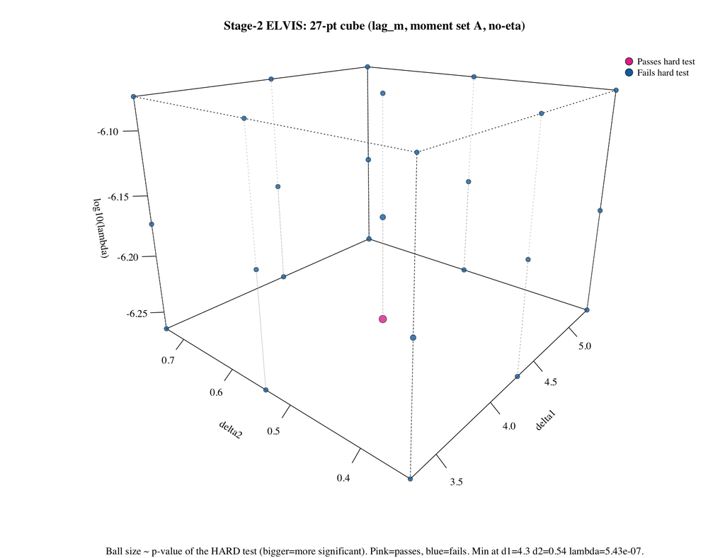

## Headline Estimates

Table 1

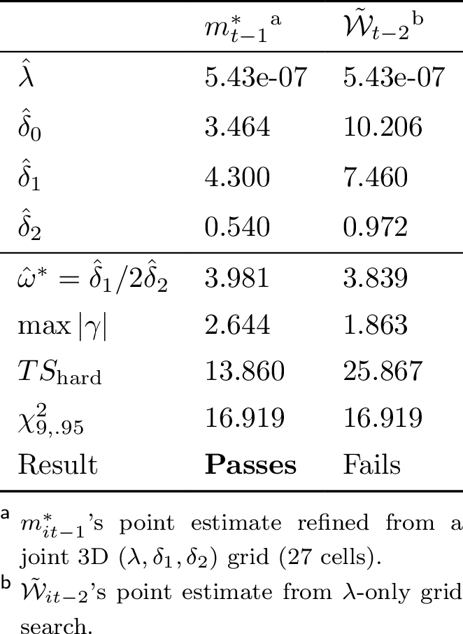

## What Detection Probability Does This Imply?

- Mean $\gg$ Median for both instruments; a right-skewed evasion distribution
- P99 $\to$ Max: detection probability jumps from 1-2% at the 99th percentile, to ~37% for the most aggressive evader (0.5%-trimmed sample)
- A handful of extreme evaders pull $E[e]$ **up** *and* the fitted $\hat\lambda$ **down**

Table 2

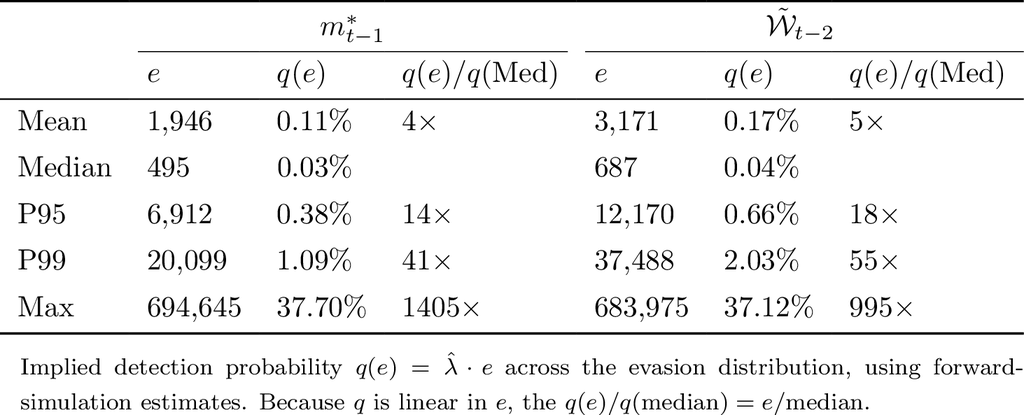

## Notes for Discussion

- **$\hat\lambda$ is very small**: few aggresive evaders dominate the estimate, the model is trying to fit a straight line over a highly right-skewed distribution.
  - Mechanically, selecting a functional form for the probability of detection imposes a ceiling probability
  - Assuming all unincoporated firms with non-zero sales tax rate on purchases, $\tau_P$, evade implies all firms evade below the ceiling (normalization)
  - We could
    - trim sample more (currently 0.5%)
    - impose a normalization (e.g. prob for 99th evaders=50%, prob)
    - use a non-linear prob of detection
  - At first, I tought $\delta_0$ and $\lambda$ we’re competing to set the level of evasion, but the estimates suggest $\lambda$ is truly different from zero even though $\delta_0$ has been profiled in all grid searches
- **($\hat\delta_1, \hat\delta_2$)**: it seems they are truly being identified by the curvature of the evasion distribution and productivity $\omega$. The $\omega^*$ is steady among grid searches and under the correct moments they come up with correct signs always

## $\lambda$ Search

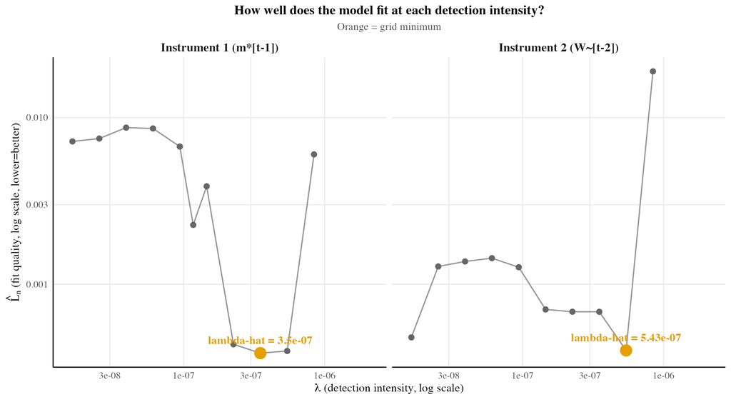

## 2D $\delta$ Search

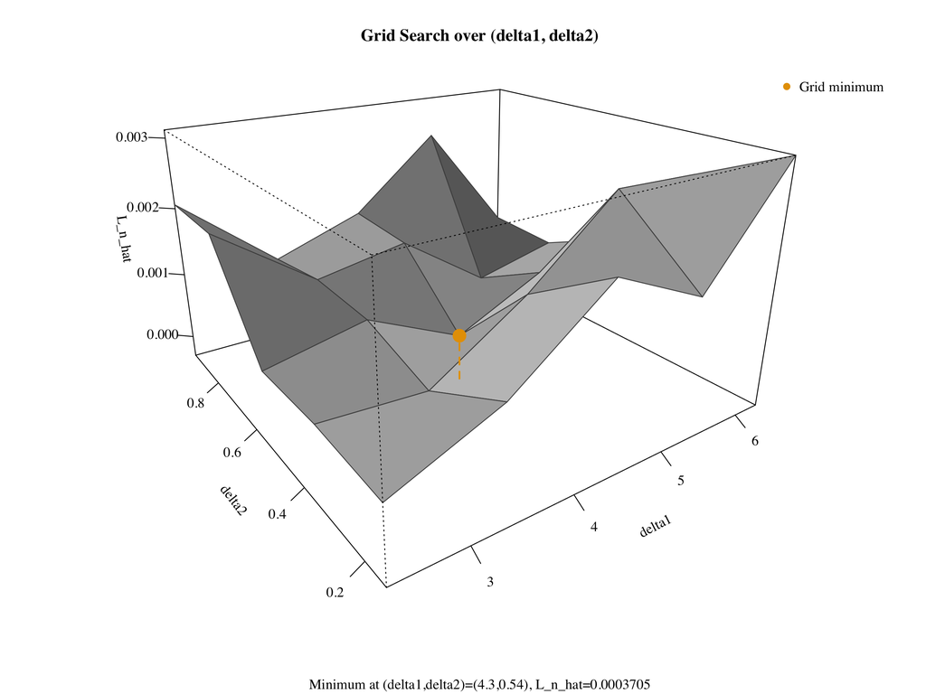

## Trimming Sample

Since few aggressive evaders were pushing the estimates of $\lambda$ down, I trimmed the sample at different percentiles of $M^*$ to test sensitivity of the estimates.

- At 0.5% trim, $\lambda$ seems to stabilize before jumping or start waving too much
- $\delta$’s looked stable across the trim range, confirming that they were fitting the curvature of evasion, and lambda the level accross firms

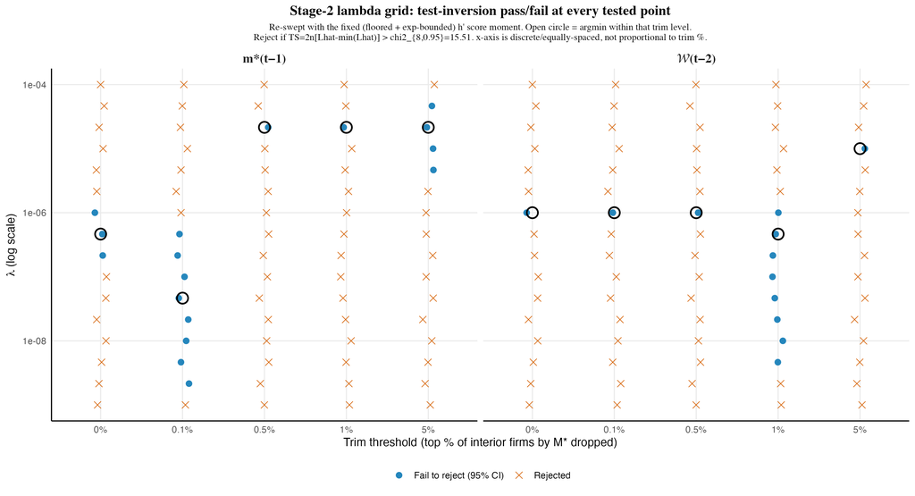

## How the Test Works

Test statistic at a candidate $\theta$: $TS(\theta)=2n\hat L_n(\theta)$, profiled over $\gamma$ (and any nuisance parameters).

- Reported test: reject $\theta$ if $TS(\theta)>\chi^2_{d_g,.95}$ ($d_g$ = number of moments) (**Theorem F.1**, Appendix F. Schennach 2014)

# Laffer Curve (Counterfactual Question)

## Increasing Efficiency in the Counterfactual Exercise

Motivation and theoretical derivation: Section 2.1 ; Implementation: Section 3.14

**Goal:** use a control variate (Hendry 1984; Davidson and MacKinnon 1992) to improve *efficiency* (reduce variance) of the counterfactual test of candidate revenue levels

**Why:** Government tax revenue displays large heterogeneity in *firm size* (large firms pay signifcantly more sales tax than small ones). We want to *control* for cross firm heterogeneity and focus on changes in tax revenue due to changes in the tax rate.

**How:** I observe firms sales tax paid on sales, $\tau_{S,it}P_tY_{it}$. By construction, $\tau_{S,it}P_tY_{it}$ correlates with government tax revenue almost perfectly. Subtract off the size-driven, predictable part of revenue before testing, a classic control-variate variance-reduction technique employed in MC simulations (Hendry 1984; Davidson and MacKinnon 1992)

**Interpretation:** the estimator remains **unbiased** for expected revenue $E[R_i(\Delta)]$. CV removes part of the sampling variance irrelevant for changes in $\tau_P$ but leaving cross-firm identifying variation that do depend on $\theta,\gamma$ and idiosyncratic noise.

## Control-Variate Moment — Details

$$g_{R,i}^{\text{adj}} = \Big[\frac{R_i(\Delta)}{pgdp_i}-\hat\beta\,\frac{t1_i}{pgdp_i}\Big] - \big[R-\hat\beta\,\mu_c\big]$$

- $\hat\beta=0.9988$ (OLS, pooled across tested $\Delta$’s), $\mu_c=E[t1_i/pgdp_i]$, both fixed and precomputed
- $E[g^{\text{adj}}_{R,i}]=E[g_{R,i}]$ exactly for *any* $\hat\beta$
- Beats industry$\times$year TWFE decisively (38-41x vs. 2.5x), zero added dimensions, no small-cell risk (100/318 TWFE cells have $<30$ obs)
- Valid because the only open channel is undetected evasion through changes in $\tau_P$. Tax reveneu from sales taxes on sales is kept fixed

## Testing the Laffer Curve

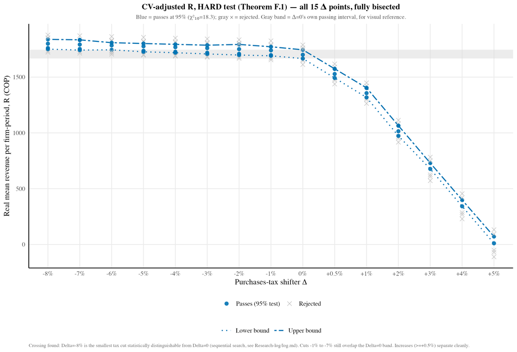

Every point is a real candidate revenue level, tested against the data (95% confidence, gray band = current policy’s own interval)

## Headline Result

- A tax **increase** of **0.5%** is already statistically distinguishable from current policy
- A tax **cut** increases tax revenue, but the gain only becomes statistically distinguishable at the **8%** cut—
- Both results come from a formal statistical test, not a point estimate

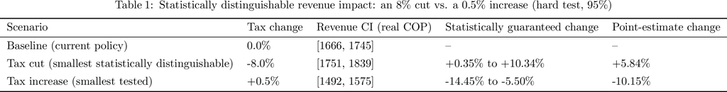

## Why

Linear $q$ + linear $\kappa$ $\Rightarrow$ new evasion is exactly linear in the firm’s own baseline evasion, with an intercept identical across every firm:
$$\tilde e(\Delta)=\frac{e_i+\Delta/(2\lambda)}{1+\Delta}$$

Whether this looks like *everyone moves together* or *heterogeneous, firm-by-firm* is a horse race between $e_i$ and $\Delta/(2\lambda)$. Enforcement is estimated to be weak ($\hat\lambda$ tiny), so $\Delta/(2\lambda)$ wins: a tax increase shifts every firm by roughly the same large amount, while a cut removes evasion firm-by-firm — small evaders reach zero first, so the aggregate response is gradual instead of a jump.

# Estimating Tax Evasion by Deconvolution

## Objective

- Empirical exercise to motivate structural model

## What can be deconvoled and what can’t

**Convolution (Meister, 2009)**

The density of the sum of two **independent** random variables is equal to the **convolution** of the densities of both addends; hence

$$f_V = \int f_\varepsilon(V - u)f_u(u)du$$

Under $\varepsilon \ind M, e$ and $e \ind M$, with known $f_\varepsilon$ and $u=\ln\left(\frac{M+e}{M}\right)$. Also $M^*=M+e$, and $V=u+\varepsilon$.

Then, I can deconvolve:

- $f_u$: $f_V = \int f_\varepsilon(V - u)f_u(u)du$

## I don’t need $f_e$, actually

What deconvolution recovers is the **overreporting log-ratio**, $u_{it}\equiv\ln\left(\frac{M^*_{it}}{M_{it}}\right)=\ln\left(1+\frac{e_{it}}{M_{it}}\right)$,

- the *share of overreported over true inputs*
- the same object discussed previously, now given an explicit structural interpretation
- Since it’s a ratio, it’s adjusted by the firm’s true materials level and hence informative about the intensity of tax evasion
- Had I recovered $e$, I would have to normalize somehow to compare firms of different levels of material utilization

Plotting $\mathcal{V}$ and $\varepsilon$ $\hookrightarrow$

## Getting rid of the log

If I’m interested in only the density of the ratio, I can use a **density transformation**

**Theorem 1.7.1 (Hogg et al. 2019)**: Let $X$ be a continuous random variable with pdf $f_X(x)$ and support $\mathbfcal{S}_X$. Let $Y=g(X)$ where $g(x)$ is a one-to-one *[monotonic] differentiable* function on the support of $X$, $\mathbfcal{S}_X$. Denote the inverse of $g$ by $x=g^{-1}(y)$ and $dx/dy=d[g^{-1}(y)]/dy$. Then, the pdf of $Y$ is given by

$$f_Y(y)=f_X(g^{-1}(y))\Bigg|\frac{dx}{dy}\Bigg|, \text{for } y\in \mathbfcal{S}_Y$$

where the support of $Y$ is the set $\mathbfcal{S}_Y=\{y=g(x):x\in\mathbfcal{S}_X\}$

## Getting density of the ratio

Therefore, with $X=u$ and $g^{-1}(y)=\ln (1+y)$

$$f_{\frac eM}(y)= f_u\big(\ln (1+y)\big)\Bigg|\frac{1}{1+y}\Bigg|
\tag{18}$$

## Informal proof

If $U = g(R)$ for a strictly monotonic differentiable $g$, then $f_R(r) = f_U(g(r))|g'(r)|$

**Proof (via CDFs).** Take $g$ strictly increasing (your case). Then
$$F_R(r) = P(R\le r) = P\big(g(R)\le g(r)\big) = P(U\le g(r)) = F_U(g(r)),$$

using that $g$ increasing preserves the inequality direction.

Differentiate both sides in $r$:
$$f_R(r) = \frac{d}{dr}F_U(g(r)) = f_U(g(r))g'(r).$$

If $g$ were decreasing instead, the inequality flips ($P(U\ge g(r))=1-F_U(g(r))$), and differentiating introduces a minus sign that exactly cancels the sign of $g'(r)$, hence $|g'(r)|$ of the general formula.

Everything goes through unchanged conditional on $Z=z$ (just work with $F_{R|Z}(\cdot\mid z)$, $F_{u|Z}(\cdot\mid z)$ throughout).

## Discussion

Deconvolution estimates the unconditional $f_u$ because of how we set it up

- From $f_u$, we can learn the probability of a firm of overreporting $u$, $P(U<u)=\int_0^uf_u(t)dt$, or
  - the expected overreportig $\mu_u=\int u f_u(u)du$
- This is the uncoditional probability, the same for all firms regardless of their characteristics
- We might be interested in the *probability of overreporting conditional* on the firm size

## What if we are interested in the conditional density?

$$\begin{aligned}
f_{V|Z}(V\mid Z)&=\frac{f_{V,Z}(V,Z)}{f_Z(Z)}\\
&=\int f_{V|u,Z}(V\mid u,Z)\,f_{u|Z}(u\mid Z)\,du\\
&=\int f_\varepsilon(V-u)\,f_{u|Z}(u\mid Z)\,du
\end{aligned}$$

using

- $f_{V|u,Z}(V\mid u,Z)=f_{\varepsilon|u,Z}(V-u\mid u,Z)$ — $V=u+\varepsilon$ conditional on $u$
- $\varepsilon\perp(u,Z)$ **jointly**, so $f_{\varepsilon|u,Z}=f_\varepsilon$

with $u\not\ind Z$ (otherwise conditioning on $Z$ would be pointless).

## Estimating the Conditional distribution

- **Discrete/bucketed $Z$** (e.g. quintiles of $K_{it}$ or $L_{it}$): the same 1-D deconvolution separately within each bucket.
  - We’ve already looked into $E[u|Z]$
- **Continuous $Z$**: nonparametric deconvolution with a continuous covariate
  - Literature: $f_{u|V}(u|V)$ (Wang and Ye 2015), $E[Z|u]$ (Fan and Truong 1993), and $f_{Z|u}$ (Huang and Zhou 2020)
  - $f_{u|Z}$: feasible using characteristic functions and kernels
- Ideally, what I want is $f_{e|\omega}$, but that’s what $f_\psi$ is, the object I wil obtain with the structural approach

# Conditional Deconvolution — Backup

## What About the Full Distribution?

- So far: $E[u_{ijt}\mid Z_{ijt}]$, and only at 10 decile bins of $Z$
- Natural next question: the whole conditional density $f_{u\mid Z}(u\mid z)$, for $Z$ continuous
  - Is the size gradient in the *level* of evasion, its *spread*, or its *shape*?

## Aside: How Deconvolution Works

We never observe $u_{ijt}$ directly — only $V_{ijt}=u_{ijt}+\varepsilon_{ijt}$, a “blurred” version of it

- A histogram of $V$ mixes the true shape of $u$ with the noise $\varepsilon$ — the density of a sum of independent things is the *convolution* of their densities, $f_V=f_u * f_\varepsilon$
- Convolutions are hard to undo directly, but they become simple *multiplication* after a Fourier transform (the characteristic function):
  $$\phi_V(t)=\phi_u(t)\,\phi_\varepsilon(t) \quad\Longrightarrow\quad \phi_u(t)=\frac{\phi_V(t)}{\phi_\varepsilon(t)}$$
- Estimate $\phi_V$ from the data, divide by the already-known $\phi_\varepsilon$, transform back $\to \hat f_u$
- This is exactly the (unconditional) trick behind the first-stage results (Carroll and Hall 1988; Stefanski and Carroll 1990)

## Conditional Version: Add a Local Window

Same trick, done separately for each value of $Z$:

- Instead of using *all* firms to build one blurred distribution, use only firms with $Z_i$ close to $z$ — a moving local window, weighted by a kernel $K$
- Un-blur *that* local distribution the same way as before

$$\begin{aligned}
\hat\phi_{V\mid Z=z}(t)&=\frac{\sum_i K\!\left(\frac{Z_i-z}{h}\right)e^{itV_i}}{\sum_i K\!\left(\frac{Z_i-z}{h}\right)}\\[4pt]
\;\;\Longrightarrow\;\;\hat f_{u\mid Z=z}(u)&=\frac{1}{2\pi}\int e^{-itu}\,\frac{\hat\phi_{V\mid Z=z}(t)}{\phi_\varepsilon(t)}\,\omega(t)\,dt
\end{aligned}$$

- $\omega(t)$: a damping weight, standard in any deconvolution, to keep the division numerically stable
- Valid because $\varepsilon\perp(u,Z)$: within any $Z$-window, the noise is still independent of $u$ — the same assumption used throughout this section

## Is This Standard?

- (Fan and Truong 1993), already cited on the “is it feasible?” slide, addresses the *mirror-image* problem: a noisy covariate and a clean outcome (see also (Huang and Zhou 2020) for the conditional-density version of that same direction)
- Ours runs the other way — clean $Z$, noisy $u$ — which is why the conditional *mean* never needed correcting: $\varepsilon\perp Z \Rightarrow E[V\mid Z]=E[u\mid Z]$
- Only the *density* needs deconvolving, and the tool is just the classical deconvolution kernel (Carroll and Hall 1988; Stefanski and Carroll 1990), applied inside a local window — a natural combination, not (to our knowledge) a named result in the literature

## Do We Need the Full Density?

- The conditional mean already carries the headline story: evasion rises then falls with size — going further only pays off if it answers a question the mean can’t
- The one moment that would matter: the conditional **variance** $\mathrm{Var}(u\mid Z=z)$
  - Does “large firms don’t evade” mean (a) *every* large firm individually evades a little — tight distribution near zero, like the corporations — or (b) a mix of some firms still evading heavily and others near zero that cancel out in the mean?
  - 1. vs. (b) is a real audit-targeting question: under (a), size alone is a good targeting rule at the top; under (b) it isn’t — some large firms are still hiding substantial evasion behind the average
- If pushed further: the full nonparametric conditional deconvolution (previous slides) is the general method; cumulant/method-of-moments matching is a cheap over-identification check on the variance estimate, not a substitute for it

$\hookleftarrow$

# Appendix

# Naive MSM and MSL

## Recall: Two Identities From the Model

$$\mathcal{V}_{it} \equiv \ln\left(\frac{\rho_t M^*_{it}}{P_tY_{it}}\right)-\ln(\beta) = \ln\left(\frac{M^*_{it}}{M_{it}}\right)-\varepsilon_{it}
\tag{19}$$

$$\tilde{\mathcal{W}}_{it}\equiv \mathcal{W}_{it}-\alpha_K k_{it}-\alpha_L l_{it}=\omega_{it}+(1-\beta)\varepsilon_{it}
\tag{20}$$

Even though $\varepsilon_{it}$ is independent of primitives {$M^*, M, Y, K, L, \omega, \psi$}, it is *not independent* of observables built from $\mathcal{V},\tilde{\mathcal{W}}$ by construction

I need the density $f_{\varepsilon|\mathcal{V},\tilde{\mathcal{W}}}(\varepsilon|\mathcal{V},\tilde{\mathcal{W}})$ which is different from the unconditional $f_{\varepsilon}(\varepsilon)$

## Solving for $M$ and $e$

From Equation 19, I can *algebraically solve* for true inputs as function of observed variables and an the error term,

- $M_{it}=M^*_{it}\textbf{e}^{-\mathcal{V}_{it}-\varepsilon_{it}}$.

Therefore,

$$\begin{aligned}
e_{it}=&M^*_{it}-M_{it}\\
=&M^*_{it}\left(1-\textbf{e}^{-\mathcal{V}_{it}-\varepsilon_{it}}\right)
\end{aligned}$$

- $\varepsilon_{it}$ is not observed firm-by-firm, only its distribution $f_\varepsilon$
- not a literal point recovery of $e_{it}$, but the map that could be evaluated for some draw of $\varepsilon^{(s)}\sim\hat f_\varepsilon$

## Recast in terms of one unobservable

I can do the same and solve for $\omega_{it}$ from Equation 20

For each value of $\varepsilon$ everything else is pinned down:

$$e_{it}(\varepsilon)=M^*_{it}\big(1-\textbf{e}^{-\mathcal V_{it}-\varepsilon}\big)
\tag{21}$$

$$\omega_{it}(\varepsilon)=\tilde{\mathcal W}_{it}-(1-\beta)\varepsilon
\tag{22}$$

$$\psi_{it}(\varepsilon)=h\big(e_{it}(\varepsilon)\big)-\delta_0+\delta_1\,\omega_{it}(\varepsilon)-\delta_2\omega_{it}(\varepsilon)^2
\tag{23}$$

## Why not simulated GMM with instruments?

The problem is the non-linear term,

$$\begin{aligned}
h(e(\varepsilon^{(s)},\mathcal{V}))=&\ln\!\big(1-2\lambda M^*_{it}(1-\textbf{e}^{-\mathcal V_{it}-\varepsilon})\big)\\
&=\ln\!\big(1-2\lambda M^*_{it}\big(1-\textbf{e}^{-\ln\left(\frac{M^*_{it}}{M_{it}}\right)+\varepsilon_{it}-\varepsilon^{(s)}}\big)\big)\\
&=\ln\!\big(1-2\lambda \underbrace{\left(M^*_{it}-M_{it}\textbf{e}^{\varepsilon_{it}-\varepsilon^{(s)}}\right)}_{\ne e_{it}}\big)\\
\end{aligned}$$

The moment to holds under $\varepsilon_{it}$, the realized measurement error for firm $it$

I cannot use instruments to make it *go away* with an independence assumption

To integrate it out I would need $E[h(e(\varepsilon,\mathcal{V}))|\mathcal{V}]=\int h(e(\varepsilon,\mathcal{V}))f(\varepsilon|\mathcal{V})d\varepsilon$ (Gouriéroux and Monfort 1996)

## Testing with data

I simulate $\varepsilon^{(s)}$, S=250, from $\hat{f_{\varepsilon}}$, efficient GMM objective weigthed by $\hat\Omega^{-1}$, and test the J-statistic against its $\chi^2_{d_g}$ distribution

$\varepsilon^{(s)}$ drawn from CORP firms’ empirical distribution, feasibility-filtered ($e>0,M>0$);

I tested the overidentified case ($d_g=5>d_{\theta}=4$): $g(\theta)=(\psi,\psi\omega,\psi\omega^2,\psi\ln M,\varepsilon h')$ (last moment is a score term for $\lambda$; $\psi\ln M$ is the overidentifying moment). I report the J-statistic, $J=n\hat L_n$, against $\chi^2_{5,.95}=11.07$.

## Results of the test

Table 3

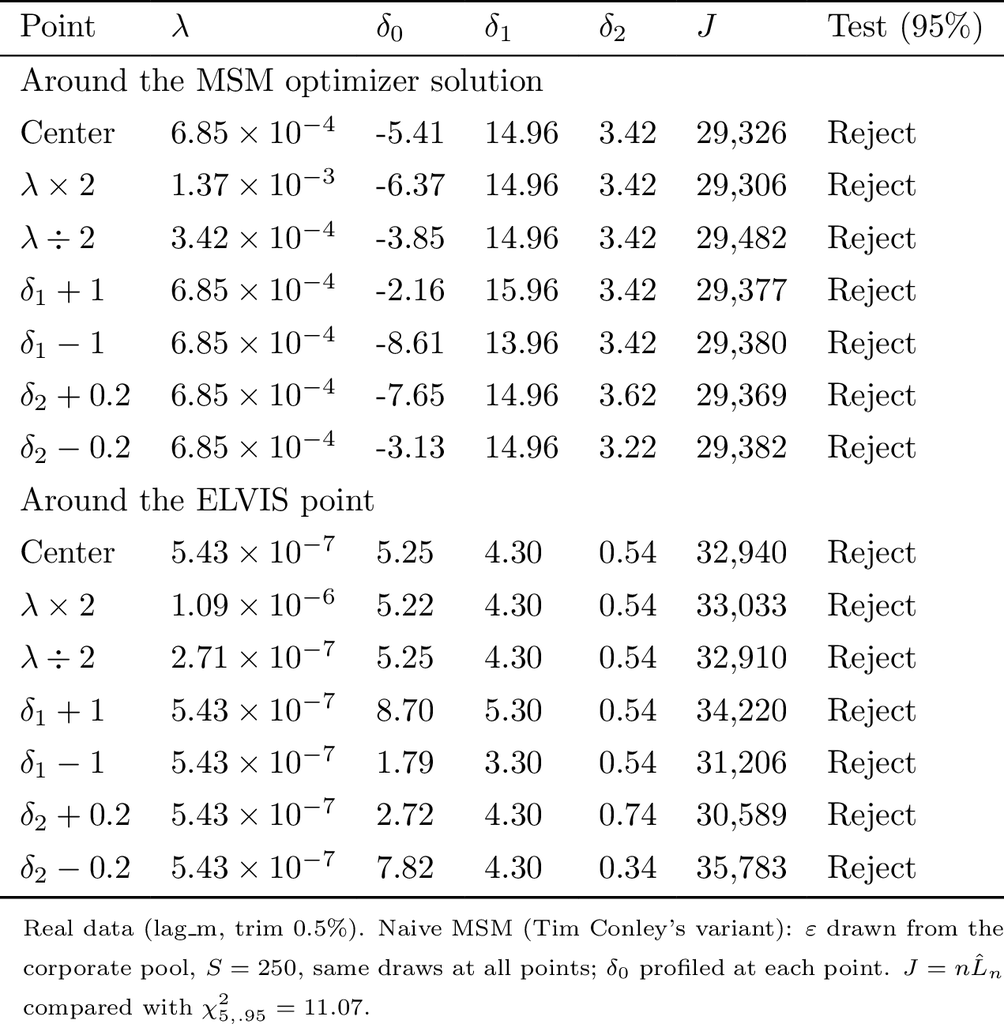

## The two grid searches

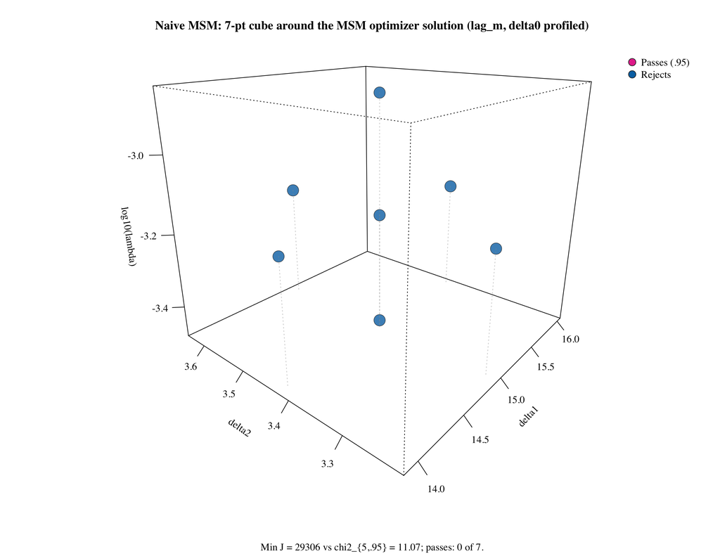

Around the MSM optimizer solution

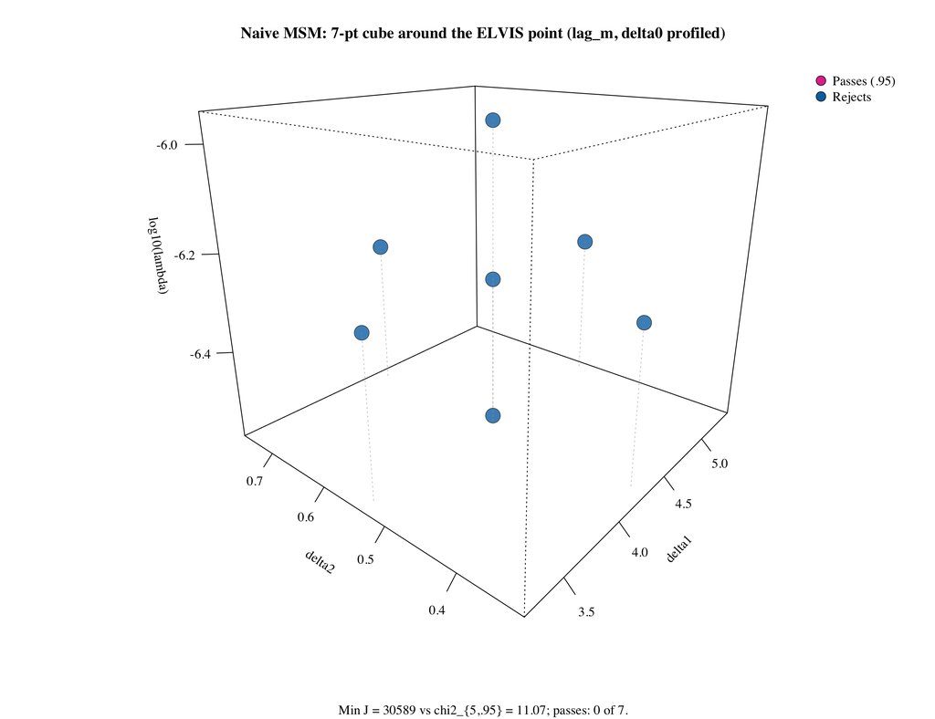

Around the ELVIS point

Center and six adjacent points ($\lambda\times/\div2$, $\delta_1\pm1$, $\delta_2\pm0.2$), $\delta_0$ profiled. Blue = rejects at 95%.

- Naive MSM rejects at **all 14 points**: $J\approx29{,}000$–$36{,}000$ against $\chi^2_{5,.95}=11.07$
- Around its own optimizer $J$ barely moves (under 1%): a flat ridge, not a sharp minimum
- Around the ELVIS point it rejects just as hard: the test favors neither

## vs. ELVIS

## What would a *correct* MSM need?

The moment is $E[\psi\mid\text{firm's own data}]$, not $E[\psi]$.

- Unconditionally, $E[\psi]=\int\psi f_\psi\,d\psi=0$ by normalization — nothing to simulate
- The problem: $(e_{it},\omega_{it})$ are not observed firm-by-firm
- Firm $i$ only reveals $o_{it}=(\mathcal V_{it},\tilde{\mathcal W}_{it},M^*_{it})$
- A valid simulated moment must average over the firm’s **posterior** for $\varepsilon$ given $o_{it}$

## Step 1 — the joint law of the latents

Primitives are independent, so the joint is the product:
$$f(\psi,\omega,\varepsilon)=f_\psi(\psi)\,f_\omega(\omega)\,f_\varepsilon(\varepsilon)$$

- Equivalently in $(e,\omega)$: $f(e,\omega)=f(e\mid\omega)\,f(\omega)$
- The FOC makes $e$ a monotone function of $\psi$ at fixed $\omega$, so
  $$f(e\mid\omega)=f_\psi\big(\psi(e,\omega)\big)\,\big|h'(e)\big|$$
- Knowing $f_\varepsilon$ is not enough: **$f_\psi$ sits inside $f(e\mid\omega)$**

## Step 2 — condition on the firm’s data

Given $o_{it}$, the latents are pinned to a curve indexed by $\varepsilon$:
$$e(\varepsilon)=M^*_{it}\big(1-\textbf{e}^{-\mathcal V_{it}-\varepsilon}\big),\qquad
\omega(\varepsilon)=\tilde{\mathcal W}_{it}-(1-\beta)\varepsilon$$

- The double integral over $(e,\omega)$ collapses to a **single** integral over $\varepsilon$
- $\omega$ is not free: it is tied to the observables through $\tilde{\mathcal W}_{it}$ (and its AR(1) link to the lag), so $f_\omega f_\varepsilon$ is the *prior*, not the conditional
- The change of variables adds the Jacobian $J_i(\varepsilon)=|h'(e)|\,M^*_{it}$

## Step 3 — the posterior weights

$$w_i(\varepsilon)=f_\psi\big(\psi(\varepsilon)\big)\,J_i(\varepsilon)\,f_\omega\big(\omega(\varepsilon)\big)\,f_\varepsilon(\varepsilon)$$

$$E[\psi\mid o_{it}]=\frac{\int\psi(\varepsilon)\,w_i(\varepsilon)\,d\varepsilon}{\int w_i(\varepsilon)\,d\varepsilon}$$

- Naive MSM sets $w_i=f_\varepsilon$ — it drops $f_\psi\cdot J_i\cdot f_\omega$
- The **denominator is exactly firm $i$’s MSL likelihood** (Equation 28)

## Conclusion: correct MSM $\Rightarrow$ MSL

- Correct MSM needs $f_\psi$ in the weights, and $f_\psi$ is the unknown
- The only way to get $f_\psi$ is to maximize $\prod_i\int w_i\,d\varepsilon$ — that is MSL
- Once MSL is run, the weighted moment adds nothing: same ingredients, less efficient
- So: skip MSM and do MSL. ELVIS remains the $f_\psi$-free robustness check

## Two alternative solutions

ELVIS: doesn’t need $f_\varepsilon$ or $f_\psi$ or the other densities. Grid search over $\theta$ and solves for an exponential tilt of the sampler (Schennach 2014)

- Implemented in my summer paper. Strategy validated by Nail. Convoluted to explain, but practical. Preliminary estimates and counterfactual results already done.

Current fit: $\hat\lambda=5.427\times10^{-7}$, $\hat\delta_1=4.3$, $\hat\delta_2=0.54$, $\hat L_n\approx0.0002$ ELVIS preliminary results

MSL: deriving the density of observables and mapping to unobservables using a density transformation.

- Feasible but resulting density needs additional density of the AR(1) process of productivity and of the lag of $\varepsilon$, and integrating out two variables, $\varepsilon_{it}$ and $\varepsilon_{it-1}$. MSL delivers estiamtes of $\theta$ and $f_\psi$

## Testing each estimator at each other’s best point

Table 4

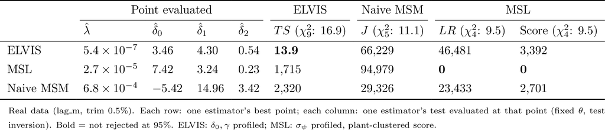

- **ELVIS** does not reject its own point and rejects the other two by a large factor
- **Naive MSM** rejects every point, including its own minimum, and, in simulations, the true $\theta$: the test cannot discriminate
- **MSL** rejects ELVIS’s point, but it is parametric: it imposes normal $f_\psi,f_\varepsilon,f_\omega$, so this is the best point *under that specification*. Its tests have no goodness-of-fit component

## Why ELVIS

- ELVIS leaves the distribution of the unobservables free: it needs only $\hat\beta$ from stage 1, never $f_\psi$ or $f_\varepsilon$
- MSL’s fit depends on shapes we do not know to be true, and its unconditional $f_\omega$ is biased in simulations
- Choice by practicality: reasonable estimates and robustness to parametric assumptions
- Next: refine MSL (conditional $f_\omega$, skewed $f_\varepsilon$, logspline $f_\psi$) as a robustness check

# Maximum Simulated Likelihood (MSL)

## Theorem 7.5.3 Change of Variables in $R^n$ Judd (1998)

Assume that $\Phi: X \subset R^n \to R^n$ is $C^1$ and that there is a $C^1$ inverse map $\Phi^{-1}: Y \subset R^n \to X$ where $Y=\Phi(X)$ and $Y$ and $X$ are open. If $f$ is integrable on $X$, then

$$\int_Y f(y)dy = \int_Xf(\Phi(x))|\det J(\Phi)(x)| dx,$$

where $J(\Phi)(x)$ is the Jacobian of $\Phi$ at $x$.

## Corollary: Density transformation

Let $f_X(x)$ be the joint pdf of $X$, $B$ any region in the support of $Y$, and $A=\Phi^{-1}(B)$

For $Y=\Phi(X)$: $P(X\in A)=P(\Phi(X)\in\Phi(A))=P(Y\in B)$. Apply the theorem with $\Psi\equiv\Phi^{-1}$ in place of $\Phi$ ($\Phi^{-1}$ is $C^1$ with $C^1$ inverse $\Phi$) to $g=f_X\cdot\mathbf 1_{A}$:
$$P(X\in A)=\int_{A}f_X(x)\,dx=\int_B f_X\big(\Phi^{-1}(y)\big)\,\big|\det J\Phi^{-1}(y)\big|\,dy.$$

Since $B$ is arbitrary, and using $J\Phi^{-1}(y)=[J\Phi(x)]^{-1}$ (inverse function theorem) at $x=\Phi^{-1}(y)$, then, the joint pdf of $Y$ is:
$$f_Y(y)=\frac{f_X(x)}{|\det J\Phi(x)|}\bigg|_{x=\Phi^{-1}(y)}
\tag{24}$$

## Target Density

To find the correct target density of observables, note that, given ($K_{it},L_{it}$), the variables ($\mathcal{V}_{it},\tilde{\mathcal{W}}_{it}$ ) form an affine map in the ($Y_{it},M^*_{it}$)-space,

$$\mathcal V_{it}=m^*_{it}-y_{it}+c_1 \tag{\ref{eq-eva-emp} rearranged}$$

$$\tilde{\mathcal W}_{it}= y_{it}-\beta (m^*_{it}-\mathcal V_{it})-\alpha_Kk_{it}-\alpha_Ll_{it} \tag{equivalent to \ref{eq-tilde-big-w}}$$

where $c_1\equiv \ln\left(\frac{\rho_t}{P_t\beta}\right)$

Substituting the first equation into the second cancels the $m^*_{it}$ terms exactly:

$$\tilde{\mathcal W}_{it}=(1-\beta)\,y_{it}+\beta c_1-\alpha_Kk_{it}-\alpha_Ll_{it}
\tag{25}$$

## $\Phi$ is a linear bijection in $(y_{it},m^*_{it})$-space

$$\Phi:(y_{it},m^*_{it})\;\mapsto\;(\mathcal V_{it},\tilde{\mathcal W}_{it})$$

$$\begin{pmatrix}\mathcal V\\ \tilde{\mathcal W}\end{pmatrix}
=\underbrace{\begin{pmatrix}-1 & 1\\ 1-\beta & 0\end{pmatrix}}_{A}
\begin{pmatrix}y\\ m^*\end{pmatrix}
+\begin{pmatrix}c_1\\ \beta c_1-\alpha_Kk-\alpha_Ll\end{pmatrix}.$$

Since $\det A = -(1-\beta)\ne0$ ($0<\beta<1$) $\implies$ $\Phi$ is an affine bijection

- $\implies$ ($\mathcal{V}_{it},\tilde{\mathcal{W}}_{it}$) contain the same information as ($Y_{it},M^*_{it}$)
- Therefore, the correct target density $f_{\mathcal V,\tilde{\mathcal W}\mid K,L}$
- **No need** to include $M^*$ in the joint density or condition on ($\mathcal{V}$ contains all information of $M^*$)

## Conditioning on $\omega_{it-1}$ instead of $(K_{it},L_{it})$

Due to the Markov process of productivity, $\omega_{it}=g(\omega_{it-1})+\eta_{it}$, $\eta_{it}\ind(\omega_{it-1},k_{it},l_{it})$,

$$f_{\omega_{it}\mid \omega_{it-1},K_{it},L_{it}}(\omega_{it})=f_{\omega_{it}\mid \omega_{it-1}}(\omega_{it})=f_\eta\big(\omega_{it}-g(\omega_{it-1})\big)$$

Conditional on $\omega_{it-1}$, the only randomness left in $\omega_{it}$ is $\eta_{it}$, which doesn’t depend on $(K_{it},L_{it})$

- $\omega_{it-1}$ is a **sufficient statistic**: once it’s known, $(K_{it},L_{it})$ adds nothing.

## Setting $\Phi$ in the $(\psi_{it},\omega_{it},\varepsilon_{it})$-space

$\Phi:(\psi_{it},\omega_{it},\varepsilon_{it})\mapsto(\mathcal V_{it},\tilde{\mathcal W}_{it},a)$, padding with the auxiliary $a\equiv\varepsilon_{it}$ so $\Phi:\mathbb R^3\to\mathbb R^3$ matches the theorem’s dimension requirement:

Define $G(\psi_{it},\omega_{it})\equiv u\big(e^*(\psi_{it},\omega_{it})\big)$,

- where $u(e)=\ln\!\big((M_{it}+e)/M_{it}\big)$, holding $M_{it}$ fixed as $e$ varies ($M\perp e\mid\omega$), and
- $e^*(\psi_{it},\omega_{it})=h^{-1}(\delta_0-\delta_1\omega_{it}+\delta_2\omega_{it}^2+\psi_{it})$ inverts the FOC for $e_{it}$,
  $$\mathcal V=G(\psi,\omega)-\varepsilon,\qquad \tilde{\mathcal W}=\omega+(1-\beta)\varepsilon,\qquad a=\varepsilon$$
- Like $(K_{it},L_{it})$ before, $\omega_{it-1}$ does not enter the map

## Conditional density

Let $J_i(\varepsilon_{it})=|\det J\Phi^{-1}|$, then,

$$\begin{aligned}
f&_{\mathcal V_{it},\tilde{\mathcal W}_{it}\mid \omega_{it-1}}(\mathcal V_{it},\tilde{\mathcal W}_{it})=\\
&\int f_\psi\big(\psi(\varepsilon_{it})\big)\,J_i(\varepsilon_{it})\,f_\eta\Big(\omega(\varepsilon_{it})-g(\omega_{it-1})\Big)\,f_\varepsilon(\varepsilon_{it})\,d\varepsilon_{it}.
\end{aligned}
\tag{26}$$

Assuming $\psi_{it},\varepsilon_{it}\perp(K_{it},L_{it})\mid\omega_{it-1}$

## Since $\omega_{it-1}$ isn’t observed, use $\tilde{\mathcal W}_{it-1}$

$\tilde{\mathcal W}_{it-1}$ is firm-$i$ *data*

- $\varepsilon_{it-1}$ unobserved, but known density $f_\varepsilon$ (stationarity) and
- already assumed independent $\varepsilon_{it-1}\perp\varepsilon_{it},\eta_{it}$ in productivity’s AR(1) estimation
- extending $\varepsilon_{it-1}\perp\psi_{it}$ (additional assumption)
- therefore, we can marginalize $\varepsilon_{it-1}$ with an ordinary integral,

## Likelihood contribution of a firm

$$\begin{aligned}
f_{\mathcal V_{it},\tilde{\mathcal W}_{it}\mid \tilde{\mathcal W}_{it-1}}&(\mathcal V_{it},\tilde{\mathcal W}_{it}|\tilde{\mathcal W}_{it-1})=\\
\iint &f_\psi\big(\psi(\varepsilon_{it})\big)\,J_i(\varepsilon_{it})\,f_\eta\Big(\omega(\varepsilon_{it})-g\big(\tilde{\mathcal W}_{it-1}-(1-\beta)\varepsilon_{it-1}\big)\Big)\\
&\times f_\varepsilon(\varepsilon_{it})\,f_\varepsilon(\varepsilon_{it-1})\,d\varepsilon_{it}\,d\varepsilon_{it-1}.
\end{aligned}
\tag{27}$$

## Recovering $f_\eta$

Define the residual used in the AR(1) productivity process,
$$\begin{aligned}
\zeta_{it}\equiv{}&\mathcal W_{it}-\alpha_Kk_{it}-\alpha_Ll_{it}-\gamma_0-\gamma_1\big(\mathcal W_{it-1}-\alpha_Kk_{it-1}-\alpha_Ll_{it-1}\big)\\
={}&(1-\beta)\varepsilon_{it}-\gamma_1(1-\beta)\varepsilon_{it-1}+\eta_{it},
\end{aligned}$$

a sum of three mutually independent variables, two with known densities, $f_\varepsilon$. Fourier deconvolution recovers the third:
$$\phi_\eta(t)=\frac{\phi_\zeta(t)}{\phi_\varepsilon\big((1-\beta)t\big)\,\phi_\varepsilon\big(-\gamma_1(1-\beta)t\big)}\ \longrightarrow\ f_\eta,$$

## The Jacobian matrix

$$J\Phi=\frac{\partial(\mathcal V,\tilde{\mathcal W},a)}{\partial(\psi,\omega,\varepsilon)}=
\begin{pmatrix} G_\psi & G_\omega & -1\\ 0 & 1 & 1-\beta\\ 0 & 0 & 1\end{pmatrix}$$

where $G_\psi\equiv\partial G/\partial\psi$ and $G_\omega\equiv\partial G/\partial\omega$

## Determinant

Expand along column 1 (only $G_\psi$ is nonzero there):
$$\det J\Phi = G_\psi\cdot\det\begin{pmatrix}1 & 1-\beta\\ 0&1\end{pmatrix}=G_\psi\cdot1=G_\psi$$

- $G_\omega$ never enters because every cofactor multiplying it comes from a zero in column 1.
- Mechanically: $\tilde{\mathcal W}=\omega+(1-\beta)\varepsilon$ has **unit coefficient on $\omega$**, a flat translation, so it contributes no curvature.
- A Jacobian only appears where the map is genuinely curved: the $\psi\to\mathcal V$ link through $G$, not $\omega\to\tilde{\mathcal W}$.

## Unpacking $G_\psi$

$G=u\circ e^*$, so by the chain rule $G_\psi=u'(e^*)\cdot e^*_\psi$.

- $u'(e)$: from $u(e)=\ln(M_{it}+e)-\ln M_{it}$, with $M_{it}$ fixed,
  $$u'(e)=\frac{1}{M_{it}+e}$$
  evaluated at $e=e^*$, $M_{it}+e^*=M^*_{it}$, $\implies u'(e)=1/M^*_{it}$
- $e^*_\psi$: differentiate the FOC identity $\psi=h(e^*(\psi,\omega))-\delta_0+\delta_1\omega-\delta_2\omega^2$ w.r.t. $\psi$ (implicit function theorem, valid since $h'\neq0$):
  $$1=h'(e^*)\cdot e^*_\psi \quad\Longrightarrow\quad e^*_\psi=\frac{1}{h'(e^*)}$$

Combine:
$$G_\psi=\frac{1}{M^*_{it}\,h'(e)}$$

## Assembling $J_i(\varepsilon)$

From Equation 24, the multiplying factor is $1/|\det J\Phi|=1/|G_\psi|$:
$$J_i(\varepsilon)\equiv\frac{1}{|G_\psi|}=\big|h'(e)\big|\,M^*_{it}$$

Every piece is traceable: - $|h'(e)|$ from inverting the FOC ($\psi\to e$), - $M^*_{it}$ from the log-ratio definition ($e\to\mathcal V$, holding the *true* $M_{it}$ fixed) - they multiply because $G=u\circ e^*$ is a **composition**, so the chain rule stacks them.

## Marginalizing out the auxiliary

Applying the density formula gives the joint density of $(\mathcal V,\tilde{\mathcal W},a)$, but only $(\mathcal V,\tilde{\mathcal W})$ are observed;

- Integrating $a$ out (an ordinary single integral, not part of the theorem) gives the likelihood contribution of firm $i$:

$$f_{\mathcal V,\tilde{\mathcal W}}(\mathcal V_{it},\tilde{\mathcal W}_{it})=\int f_\psi\big(\psi(\varepsilon)\big)\,J_i(\varepsilon)\,f_\omega\big(\omega(\varepsilon)\big)\,f_\varepsilon(\varepsilon)\,d\varepsilon
\tag{28}$$

A 3-for-3 change of variables that ends in a 1-D integral:

- the theorem handles the square transformation and hands back a Jacobian;
- marginalizing the unobserved auxiliary coordinate is the separate, ordinary step left over once the theorem’s job is done.

## Simulated log-likelihood

$$\begin{aligned}
\mathcal L(\theta,f_\psi)=\sum_{i\in\text{Unincorp}}\ln\!\left(\int f_\psi(\psi(\varepsilon))\,J_i(\varepsilon)\,f_\omega(\omega(\varepsilon))\,f_\varepsilon(\varepsilon)\,d\varepsilon\right)
\end{aligned}
\tag{29}$$

## Simulating the likelihood

Approximate Equation 28 by **Monte Carlo**

$$\widehat{\mathcal L}_i(\theta)=\frac1S\sum_{s=1}^S f_\psi\big(\psi(\varepsilon^{(s)})\big)\,J_i(\varepsilon^{(s)})\,f_\omega\big(\omega(\varepsilon^{(s)})\big),\qquad \varepsilon^{(s)}\overset{iid}\sim \hat f_\varepsilon
\tag{30}$$

- Draws $\varepsilon^{(s)}$ come from *exactly* the density $\hat f_\varepsilon(\varepsilon)\,d\varepsilon$ multiplying the integrand — this is plain Monte Carlo integration, unbiased for **any** $S\ge1$
- Alternatively, use **deterministic quadrature** to integrate Equation 28

## Why this works despite $\varepsilon$ entering $e$ nonlinearly

- $e(\varepsilon)=M^*_{it}(1-\textbf{e}^{-\mathcal V_{it}-\varepsilon})$ is nonlinear in $\varepsilon$
- But Equation 30 averages the **density value** $f_\psi(\psi(\varepsilon^{(s)}))\,J_i(\varepsilon^{(s)})\,f_\omega(\omega(\varepsilon^{(s)}))$ at each draw
  - never averages $\psi(\varepsilon^{(s)})$ *by itself*
- Monte Carlo integration of a (possibly wild) function against its own sampling density is unbiased regardless of the function’s shape
  - nonlinearity only breaks things if the reweighting is skipped
- Every simulated $\varepsilon^{(s)}\ne$ the firm’s true $\varepsilon_{it}$, almost surely
  - but draws implying an implausible $(\psi,\omega)$ pair get down-weighted by $f_\psi\cdot J_i\cdot f_\omega$; only draws near the truth carry weight,
  - so the weighted average reconstructs the correct posterior-weighted integral even though no single draw is the truth

## Convergence — a known theorem

**Lee (1992)**: if the simulator of a likelihood contribution is (i) unbiased and continuous in $\theta$, and (ii) built from draws i.i.d. across firms and replicates, then under standard M-estimation regularity (compactness, identification, dominance) the simulated-MLE is consistent and $\sqrt N$-equivalent to the infeasible exact MLE, **provided $\sqrt N/S\to0$** as $N,S\to\infty$ (fixed $S$ leaves an $O(1/S)$ bias, since $\ln(\text{average})\ne$ average of $\ln$)

- Unbiasedness (i): shown above, holds by construction
- Continuity (ii): $h$, $q$, and $J_i(\varepsilon)$ are smooth throughout the interior domain $e\in(0,\tfrac1{2\lambda})$
- Draws i.i.d. across $i,t,s$, independent of $\theta$: by construction

## An even cleaner argument: quadrature

- The preferred implementation is **deterministic quadrature**, not Monte Carlo simulation, for this 1-D integral
- Quadrature avoids simulation noise because it is deterministic and can be driven arbitrarily small by adding nodes
- The $\sqrt N/S\to0$ condition above is then moot: with negligible quadrature error, ordinary MLE consistency applies directly

## Caveat: this is a two-step estimator

- $\beta$ and $f_\varepsilon$ are **first-stage estimates**, not the truth
- Still consistent under standard conditions, but naive stage-2 standard errors ignore stage-1 estimation uncertainty
- Use the Murphy and Topel (1985) two-step correction, or bootstrap both stages jointly

## MSL plan: parametric first, then semi-parametric

1. **Parametric $f_\psi=N(0,\sigma^2_\psi)$**
   - Location normalization $E[\psi]=0$, as in ELVIS; $\delta_0$ carries the level
   - Debug, sanity-check $\hat\theta$, compare with ELVIS
2. **Semi-parametric $f_\psi$: logspline with a roughness penalty** (same estimator as for $f_u$ and $f_\omega$; Kang and Qiu (2021), Eilers and Marx (1996))
   $$f_\psi(\psi)=\exp\{s(\psi;a)-C(a)\},\quad s(\psi;a)=\sum_j a_jB_j(\psi),\quad C(a)=\ln\!\int_L^R e^{s(\psi;a)}d\psi$$
   - Penalized objective: $\sum_i\ln\!\int w_i(\varepsilon;\theta,a)\,d\varepsilon-\lambda\|D^{(d)}a\|^2$
   - Penalty order $d$ sets which moments are preserved as $\lambda\to\infty$ ($d=2$: mean; $d=3$: mean and variance, Gaussian limit)
   - Knots, support $[L,R]$ and $d$ guided by the forward-simulated $\psi$ from the ELVIS fit; $\lambda$ by BIC/CV
3. Standard errors are two-step: Murphy–Topel or a joint bootstrap

# Appendix: Is CV-$R$’s Precision Real?

## Is CV-$R$’s Precision Real?

Robustness checks requested by Nail Kashaev on the counterfactual’s control-variate correction

## The Question

Under a correctly-estimated, efficient weighting matrix $\hat\Omega^{-1}$, a moment’s own variability shouldn’t matter for a GMM/CUE test’s conclusions — so why did switching from raw $R$ to CV-adjusted $R$ turn a vacuous test into a tight, closed confidence set?

- Numerical-artifact hypothesis: is this eigenvalue truncation in $\hat\Omega^-$, not genuine information?
- Picked one concrete point to check directly: $\Delta=-4\%$, $R=\$1850$, $\theta$ fixed at the standard operating point
- Raw $R$ (fit fresh at this point): $TS\approx0.05$, passes overwhelmingly
- CV-$R$ (already fitted): $TS_{\text{hard}}=45.3$, rejects decisively

## Is It Eigenvalue Truncation?

New read-only diagnostic (`omegadiag`, `Code/C-estimator/grid_estimator.cpp`): dumps the full eigen-spectrum, truncation status ($w_k>10^{-8}\max_k w_k$, the same relative threshold behind the 2026-09-07 $h'$ score-moment bug), and per-row loadings at a fixed $(\theta,\gamma,\Delta,R)$.

**Result: truncation is essentially identical between raw $R$ and CV-$R$** — same 4 of 10 eigen-directions kept, same 6 discarded (`psi`, `eps`, `eps·om`, `eps·lnM`, `psi·om`, and the $\lambda$-score moment), in both fits, with similar condition numbers ($\sim10^7$).

$R$ loads $\approx1.000$ on its own dedicated eigen-direction, essentially nothing else — and that direction is **never** truncated, in either fit. It only differs in *rank*: raw $R$’s huge variance makes it the single largest eigenvalue in the whole system; CV-$R$’s smaller variance puts it lower — but still comfortably above the truncation floor.

## The Mechanism: Same Deviation, Different Yardstick

|  | raw $R$ | CV-$R$ |
| --- | --- | --- |
| SE | $559.4 | $13.5 |
| deviation from candidate | $82.5 | $81.6 |
| in SE units | 0.15 SEs | 6.03 SEs |
| TS from this row alone | 0.02 | 36.6 |

Back-solving “how far would raw $R$ need to be to reject from this row alone” gives $\approx\$2{,}695$ — matches raw’s own actual rejecting grid candidates ($\approx\$2{,}670$–$2{,}701$ from center) almost exactly.

- **Efficient weighting is working correctly — a lower-noise moment earns more weight for the same deviation. Not a truncation artifact.**
- $\hat\gamma$ itself barely differs between the two fits ($\gamma_{10}$, the multiplier directly on $R$: only $+15\%$) — the whole gap lives in the variance denominator, not in how hard $\gamma$ has to pull

## An Independent Check: Is $\hat\beta$ Data-Mined?

CV-$R$’s correction uses $\hat\beta=0.998838$, fitted by regressing $R_i$ on $t1_i$. Could this be inflating precision by construction?

**Test: fix $\beta=1$ exactly** — straight from the revenue identity itself, no fitting at all:
$$R_i(\Delta)-t1_i = -\tau_P\big[M_i+(1-q(e'(\Delta)))e'(\Delta)\big]$$

- New `row9_mode=theory` in `grid_estimator.cpp`: same control-variate operation, coefficient fixed rather than regression-estimated
- Smoke test at the anchor ($\Delta=0$): SE$=13.59$ vs. CV’s own SE$=13.53$ — a 0.4% difference — and $\hat L_n$ matching CV’s own to 5 significant figures

## Result: Nested Inside CV-$R$’s Own Bounds, Everywhere

Tested at all 9 of CV-$R$’s own headline $\Delta$’s. Every single implied CI nests inside CV-$R$’s own fine-resolved hard-CI, several upper bounds matching almost exactly:

| $\Delta$ | theory-implied CI (coarse) | CV-$R$’s own CI |
| --- | --- | --- |
| $-8\%$ | [1788, 1827] | [1751, 1839] |
| $-4\%$ | [1728, 1768] | [1719, 1794] |
| $0\%$ | [1701, 1745] | [1666, 1745] |
| $+1\%$ | [1356, 1403] | [1318, 1404] |
| $+2\%$ | [1015, 1064] | [973, 1065] |

**$\hat\beta=0.998838$ isn’t data-mined — it’s landing almost exactly on the value the accounting identity hands you directly.**

## A Caveat Worth Being Explicit About

Converting the theory target back to real-revenue terms adds $\mu_c=E[t1_i/pgdp_i]$, treated here as a fixed known constant — exactly the same simplification CV-$R$’s own $\hat\beta,\mu_c$ already make.

- A fully rigorous treatment would give $\mu_c$ its own sampling distribution rather than a plugged-in point estimate
- Doesn’t change the conclusion — it’s a simple, precisely-measured empirical mean, not a model-based quantity
- But it’s a direct illustration of *why* raw $R$ was so imprecise in the first place: $t1_i$’s own firm-to-firm variation was never being controlled for at all

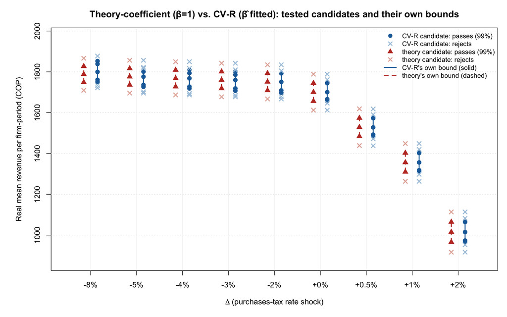

Individual tested candidates, both systems, same real-revenue axis — theory-coefficient’s passing points (red) sit in essentially the same range as CV-$R$’s (blue) at every $\Delta$.

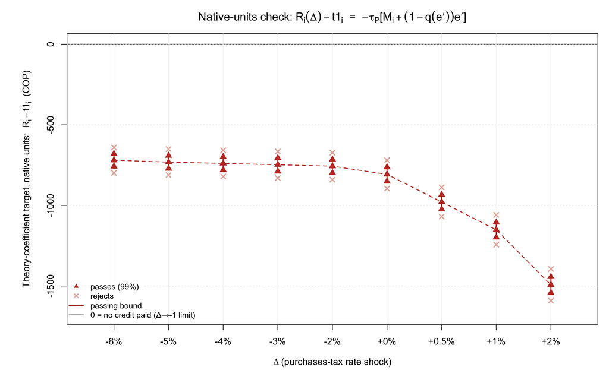

## Robustness: Done vs. Planned

- **Done:** $\theta$-free check (2026-09-14) — confirms the tight CV bounds aren’t an artifact of holding $\theta$ fixed
- **Done:** theory-coefficient validation (above) — confirms $\hat\beta$ isn’t data-mined
- **Planned:** instrument comparison, lag_m vs. lag_2_cal_W — the whole counterfactual pipeline has only ever been run for lag_m; rerunning under lag_2_cal_W’s own operating point would test whether the headline result is instrument-robust

## References

Aguiar, Victor H., and Nail Kashaev. 2020. “Stochastic Revealed Preferences with Measurement Error.” *Review of Economic Studies* 0: 1–52. https://doi.org/10.1093/restud/rdaa067.

Allingham, Michael G., and Agnar Sandmo. 1972. “Income Tax Evasion: A Theoretical Analysis.” *Journal of Public Economics* 1 (November): 323–38. https://doi.org/10.1016/0047-2727(72)90010-2.

Carroll, Raymond J., and Peter Hall. 1988. “Optimal Rates of Convergence for Deconvolving a Density.” *Journal of the American Statistical Association* 83 (404): 1184–86. https://doi.org/10.1080/01621459.1988.10478718.

Davidson, Russell, and James G. MacKinnon. 1992. “Regression-Based Methods for Using Control Variates in Monte Carlo Experiments.” *Journal of Econometrics* 54 (1-3): 203–22.

Eilers, Paul H. C., and Brian D. Marx. 1996. “Flexible Smoothing with b-Splines and Penalties.” *Statistical Science* 11 (2): 89–121. https://doi.org/10.1214/ss/1038425655.

Fan, Jianqing, and Young K. Truong. 1993. “Nonparametric Regression with Errors in Variables.” *The Annals of Statistics* 21 (4): 1900–1925. https://doi.org/10.1214/aos/1176349402.

Gouriéroux, Christian, and Alain Monfort. 1996. *Simulation-Based Econometric Methods*. Oxford University Press.

Hendry, David F. 1984. “Monte Carlo Experimentation in Econometrics.” Chap. 16 in *Handbook of Econometrics*, edited by Zvi Griliches and Michael D. Intriligator, vol. 2. North-Holland.

Hogg, Robert V., Joseph W. McKean, and Allen T. Craig. 2019. *Introduction to Mathematical Statistics*. Eigth. Pearson.

Huang, Xianzheng, and Haiming Zhou. 2020. “Conditional Density Estimation with Covariate Measurement Error.” *Electronic Journal of Statistics* 14 (1): 970–1023. https://doi.org/10.1214/20-EJS1688.

Judd, Kenneth L. 1998. *Numerical Methods in Economics*. MIT Press.

Kang, Yicheng, and Peihua Qiu. 2021. “Nonparametric Deconvolution by Fourier Transformation and Other Related Approaches.” *Handbook of Measurement Error Models*, October, 221–44. https://doi.org/10.1201/9781315101279-11.

Lee, Lung-Fei. 1992. “On Efficiency of Methods of Simulated Moments and Maximum Simulated Likelihood Estimation of Discrete Response Models.” *Econometric Theory* 8 (4): 518–52. https://doi.org/10.1017/S0266466600013310.

Murphy, Kevin M., and Robert H. Topel. 1985. “Estimation and Inference in Two-Step Econometric Models.” *Journal of Business & Economic Statistics* 3 (4): 370–79. https://doi.org/10.2307/1391724.

Schennach, Susane M. 2014. “Entropic Latent Variable Integration via Simulation.” *Econometrica* 82: 345–85. https://doi.org/10.3982/ecta9748.

Stefanski, Leonard A., and Raymond J. Carroll. 1990. “Deconvoluting Kernel Density Estimators.” *Statistics* 21 (2): 169–84. https://doi.org/10.1080/02331889008802238.

Wang, Xiao Feng, and Deping Ye. 2015. “Conditional Density Estimation in Measurement Error Problems.” *Journal of Multivariate Analysis* 133 (January): 38–50. https://doi.org/10.1016/j.jmva.2014.08.011.